# Fluoxetine microbiome analyses

Gabriel Melhado

2026-07-17

# SETUP

## Libraries

### Load all packages required for data import, manipulation, microbiome processing, statistical modelling, visualisation, and file management.

```r
# Load packages
pacman::p_load(readr, readxl, here, dplyr, tidyr, tidyverse, forcats, scales, RColorBrewer, grid, janitor, stringr, tibble, phyloseq, vegan, microbiome, microViz, ggside, pairwiseAdonis, DESeq2, ggplot2, lme4, lmerTest, glmmTMB, patchwork, Maaslin2, BiocManager)
```

# Data

## Data wrangling

### Import the experimental metadata and format sample identifiers so they match the identifiers used in the sequencing files. The sample ID column is then converted to row names and stored as a sample_data object for integration with phyloseq.

```r
# Read and prepare metadata
meta <- read_csv(here("data", "experimental_data.csv"))
# Add .fastq to sample column so that it will match the sequence data and make them row names
meta$sample_id <- paste(meta$sample_id, ".fastq", sep = "")
meta <- meta %>%
  remove_rownames() %>%
  column_to_rownames(var = "sample_id")

# Create phyloseq object
mtd_final <- sample_data(meta)
```

## Sequencing information

### Import the ASV abundance table, taxonomic assignments, and rooted phylogenetic tree produced by the sequencing pipeline. Two alternative taxonomic-classification outputs are imported here so their results can be compared before selecting one for downstream analyses.

```r
# Feature table (ASVs count and taxonomy info using Naive Bayes classifier)
biom_NB <- import_biom(
  here("data", "feature-table-tax.biom"),
  treefilename = here("data", "phylotree_mafft_rooted.nwk")
)

# Feature table (ASVs count and taxonomy info using VSEARCH)
biom_VSEARCH <- import_biom(
  here("data", "feature-table-tax_vsearch.biom"),
  treefilename = here("data", "phylotree_mafft_rooted.nwk")
)
```

# Generate phyloseq objects

## ps_NB includes raw counts and will be used for differential abundance analysis.

# Phyloseq object

### Combine the sequencing data with the experimental metadata to create the initial phyloseq object. Taxonomic rank names are standardised, and a total-sum-scaled copy is produced by converting each sample’s counts to relative abundances.

```r
# Merge feature table with metadata to create phyloseq object
ps_NB_raw <- merge_phyloseq(mtd_final, biom_NB)
# Fix tax_table so that the column names are correctly names
colnames(tax_table(ps_NB_raw)) <- c("Domain", "Phylum", "Class", "Order", "Family", "Genus", "Species")

# Total sum scaling: converts raw counts into proportions
ps_tss_raw <- transform_sample_counts(ps_NB_raw, function(x){if(sum(x) == 0){x} # avoid producing naN when the sample count is zero
  else {x / sum(x)}})
```

# Data filtering

## Taxonomy-based filtering

### Apply taxonomy-based quality control to both the relative-abundance and raw-count phyloseq objects. Features lacking phylum-level classification or assigned to chloroplasts, mitochondria, or Chlorophyta are removed because they are not part of the target bacterial community.

```r
# Remove features without a phylum-level annotation and those assigned as chloroplast or mitochondria.

# Filter datasets
ps_tss <- ps_tss_raw %>%
  subset_taxa(!is.na(Phylum) & !Phylum %in% c("", "uncharacterised")) %>%
  subset_taxa(Order != "o__Chloroplast" | is.na(Order)) %>%
  subset_taxa(Family != "f__Mitochondria" | is.na(Family)) %>%
  subset_taxa(Phylum != "p__Chlorophyta")

ps_NB <- ps_NB_raw %>%
  subset_taxa(!is.na(Phylum) & !Phylum %in% c("", "uncharacterised")) %>%
  subset_taxa(Order != "o__Chloroplast" | is.na(Order)) %>%
  subset_taxa(Family != "f__Mitochondria" | is.na(Family)) %>%
  subset_taxa(Phylum != "p__Chlorophyta")
```

## Prevalence-based filtering

### Features that show up in only a few samples may not represent real biological diversity but rather PCR/sequencing errors (such as PCR chimeras) or reagent contaminants.

### Remove low-prevalence ASVs that occur in fewer than 10% of samples. This step reduces the influence of extremely rare features that are more likely to reflect sequencing artefacts, contaminants, or poorly supported biological signals.

```r
# Prevalence filter (remove features present in less than 10% of samples)
prev_cut <- ceiling(0.10 * nsamples(ps_NB))
ps_NB <- filter_taxa(ps_NB, function(x) sum(x > 0) >= prev_cut, prune = TRUE)
```

### Compare the number of ASVs before and after filtering. This provides a direct check of how strongly the taxonomic and prevalence filters reduced the feature table.

```r
# Check the number of taxa that remain after filtering
ntaxa(ps_NB_raw)
```

```
## [1] 15768
```

```r
ntaxa(ps_NB)
```

```
## [1] 261
```

```r
# Check that no samples have been removed
nsamples(ps_NB_raw)
```

```
## [1] 129
```

```r
nsamples(ps_NB)
```

```
## [1] 129
```

```r
# Check the number of reads that were left after filtering
sum(taxa_sums(ps_NB)) / sum(taxa_sums(ps_NB_raw)) * 100
```

```
## [1] 79.55518
```

```r
summary(sample_sums(ps_NB))
```

```
##    Min. 1st Qu.  Median    Mean 3rd Qu.    Max.
##       9   13196   23032   22700   32860   45727
```

```r
mean(sample_sums(ps_NB))
```

```
## [1] 22700.02
```

```r
range(sample_sums(ps_NB))
```

```
## [1]     9 45727
```

```r
sd(sample_sums(ps_NB))
```

```
## [1] 13566.39
```

### Identify samples with fewer than 1,000 retained reads, remove them from the dataset, and then prune ASVs that become absent after sample removal. The sequencing-depth distribution is recalculated to confirm the properties of the final filtered object.

```r
# Check sequencing depth per sample
sample_depth <- sample_sums(ps_NB)

# Identify low-depth samples
low_depth_samples <- names(sample_depth[sample_depth < 1000])
low_depth_samples
```

```
## [1] "66CT7.fastq"  "65CT7.fastq"  "89HT10.fastq" "91HT10.fastq" "75LT18.fastq"
## [6] "28CT4.fastq"  "35LT14.fastq" "83CT9.fastq"
```

```r
# Remove samples with <1000 reads
ps_NB <- prune_samples(sample_depth >= 1000, ps_NB)

# Remove taxa/ASVs that are now absent after sample filtering
ps_NB <- prune_taxa(taxa_sums(ps_NB) > 0, ps_NB)

# Check new sequencing depth summary
summary(sample_sums(ps_NB))
```

```
##    Min. 1st Qu.  Median    Mean 3rd Qu.    Max.
##    1050   15920   24109   24191   33314   45727
```

```r
mean(sample_sums(ps_NB))
```

```
## [1] 24191.33
```

```r
range(sample_sums(ps_NB))
```

```
## [1]  1050 45727
```

```r
sd(sample_sums(ps_NB))
```

```
## [1] 12655.22
```

### Visualise ASV prevalence before and after filtering. The histograms show how many samples each ASV occurs in and help confirm that the low-prevalence portion of the distribution has been removed.

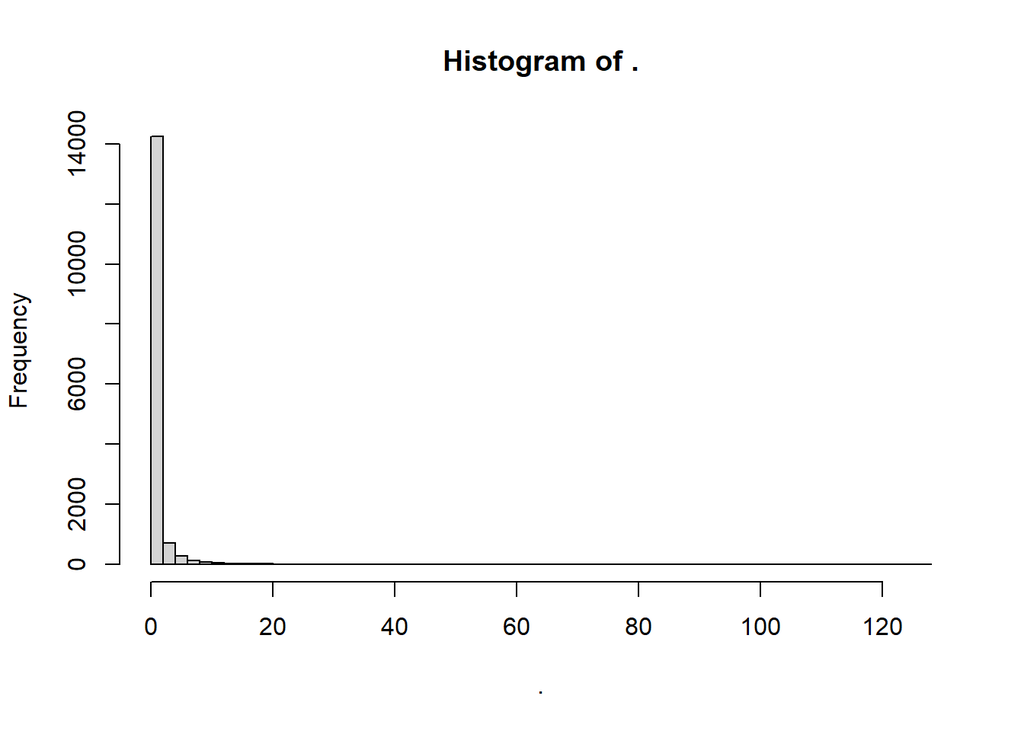

```r
# Plot histograms to ensure that early peaks have been removed
apply(otu_table(ps_NB_raw), 1, function(x) sum(x > 0)) %>%
  hist(breaks = 50)
```

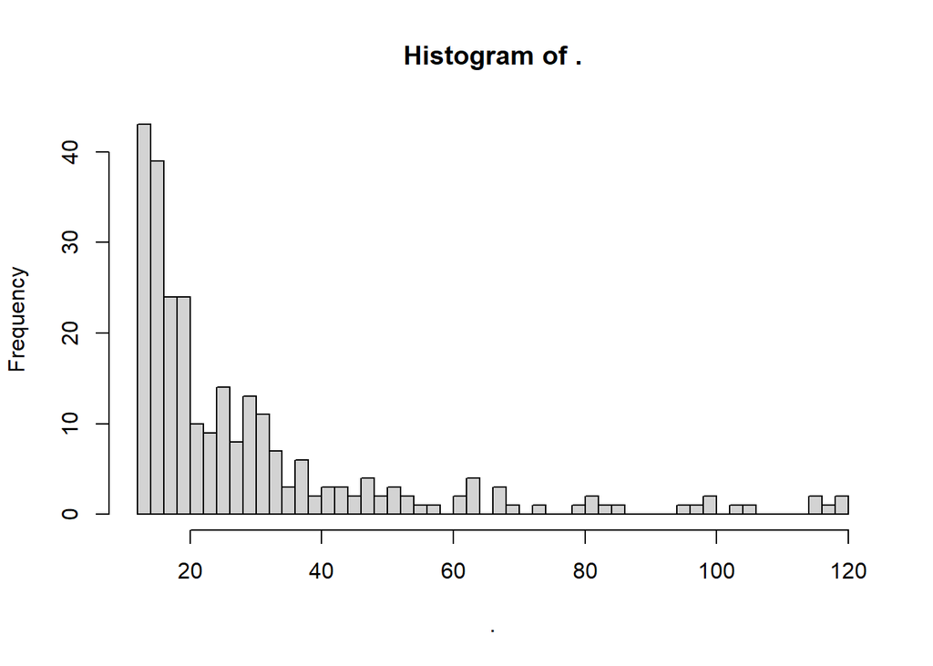

```r
apply(otu_table(ps_NB), 1, function(x) sum(x > 0)) %>%
  hist(breaks = 50)
```

# Alpha diversity

“Alpha-diversity is the diversity in a single ecosystem or sample. The simplest measure is richness, the number of species (or OTUs) observed in the sample. Other metrics consider the abundances (frequencies) of the OTUs, for example to give lower weight to lower-abundance OTUs.” - Robert Edgar

Essentially, alpha diversity measures within-sample diversity across treatments. It is used to evaluate richness and abundance of microbial communities.

Initial plot: Use the phyloseq library to investigate the alpha diversity measure of each sample across the three treatment groups. Note that we will only use a subset of these measures (explained in further detail below).

## Initial plot

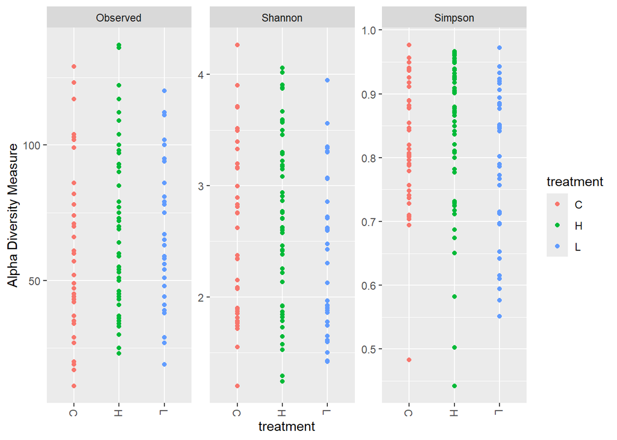

```r
plot_richness(ps_NB, x="treatment", color="treatment",
              measures = c("Observed","Shannon","Simpson"))
```

## Calculate alpha diversity

There are many different measures of alpha diversity: - Observed: The actual number of unique ASVs in a sample. Measures taxonomic richness. - ACE: Abundance-based coverage estimator. Based on the abundance of species and estimates the no. of additional species that are likely to be present but have not been observed. - Shannon: Takes into account both species richness and species evenness. It is calculated based on the logarithm of the relative abundances of species in a community. - Simpson’s Diversity Index: Takes into account the number of species present, as well as the relative abundance of each species. 1 = infinite diversity, 0 = no diversity. Measures dominance (i.e., evenness) - Fisher: Takes into account both the number of species (species richness) and the evenness of their distribution. - Chao1: Estimates the true number of species (species richness) in a community or sample, especially when some species are rare and may not be observed in the sample. It takes into account both the number of observed species and the number of rare or singleton species to provide an estimate of total species richness.

### Calculate sample-level alpha-diversity metrics and merge them with the experimental metadata. Sample identifiers are standardised before merging so that each diversity estimate is correctly linked to its treatment, tank, and other covariates.

```r
# Get alpha values for each sample
alpha <- estimate_richness(ps_NB) %>%
  as.data.frame() %>%
  rownames_to_column(var = "sample") %>%
  mutate(sample = as.character(gsub("X", "", sample)))
# Produces a warning about the lack of singletons (ASVs with a count of 1). This is OK given that the data has been denoised by AGRF, which removes singletons. Note that Chao1 should not be used as it uses singletons in its formula.

# Make sure sample IDs are included in the metadata
IDs <- meta %>%
  rownames_to_column("sample")

# Combine metadata with alpha values
alpha_mtd <- merge(x = IDs, y = alpha, by = "sample")
```

## Analysis:

Is there evidence that alpha values differ across treatment groups? Note that we only report results from Observed, Shannon, and Simpson measures of diversity.

###Test whether alpha diversity differs among fluoxetine treatments while accounting for sequencing depth and tank-level non-independence. Observed richness is modelled with a negative-binomial GLMM, whereas Shannon and Simpson diversity are analysed with linear mixed-effects models.

```r
#Tank-level replication
# add sequencing depth
alpha_mtd$reads <- sample_sums(ps_NB)[alpha_mtd$sample]
alpha_mtd$log_reads <- log(alpha_mtd$reads)


#Observed
m_observed <- glmmTMB(
  Observed ~ treatment + log_reads + (1 | tank),
  data = alpha_mtd,
  family = nbinom2()
)

summary(m_observed)
```

```
##  Family: nbinom2  ( log )
## Formula:          Observed ~ treatment + log_reads + (1 | tank)
## Data: alpha_mtd
##
##      AIC      BIC   logLik deviance df.resid
##   1134.3   1151.1   -561.2   1122.3      115
##
## Random effects:
##
## Conditional model:
##  Groups Name        Variance Std.Dev.
##  tank   (Intercept) 0.1208   0.3476
## Number of obs: 121, groups:  tank, 21
##
## Dispersion parameter for nbinom2 family (): 8.66
##
## Conditional model:
##             Estimate Std. Error z value Pr(>|z|)
## (Intercept)   2.8860     0.5314   5.431  5.6e-08 ***
## treatmentH    0.1878     0.1975   0.951   0.3416
## treatmentL    0.1437     0.2145   0.670   0.5029
## log_reads     0.1134     0.0520   2.181   0.0292 *
## ---
## Signif. codes:  0 '***' 0.001 '**' 0.01 '*' 0.05 '.' 0.1 ' ' 1
```

```r
#Shannon
m_shannon <- lmer(
  Shannon ~ treatment + log_reads + (1 | tank),
  data = alpha_mtd
)

anova(m_shannon)
```

```
## Type III Analysis of Variance Table with Satterthwaite's method
##            Sum Sq Mean Sq NumDF   DenDF F value Pr(>F)
## treatment 0.06838 0.03419     2  17.086  0.1183 0.8891
## log_reads 0.36985 0.36985     1 112.652  1.2798 0.2603
```

```r
summary(m_shannon)
```

```
## Linear mixed model fit by REML. t-tests use Satterthwaite's method [
## lmerModLmerTest]
## Formula: Shannon ~ treatment + log_reads + (1 | tank)
##    Data: alpha_mtd
##
## REML criterion at convergence: 237.2
##
## Scaled residuals:
##      Min       1Q   Median       3Q      Max
## -2.58108 -0.53826 -0.03842  0.69370  1.81728
##
## Random effects:
##  Groups   Name        Variance Std.Dev.
##  tank     (Intercept) 0.3192   0.5650
##  Residual             0.2890   0.5376
## Number of obs: 121, groups:  tank, 21
##
## Fixed effects:
##              Estimate Std. Error        df t value Pr(>|t|)
## (Intercept)   3.33652    0.73031 116.65968   4.569 1.23e-05 ***
## treatmentH    0.13980    0.31581  16.85917   0.443    0.664
## treatmentL    0.01529    0.34258  17.34374   0.045    0.965
## log_reads    -0.07959    0.07035 112.65151  -1.131    0.260
## ---
## Signif. codes:  0 '***' 0.001 '**' 0.01 '*' 0.05 '.' 0.1 ' ' 1
##
## Correlation of Fixed Effects:
##            (Intr) trtmnH trtmnL
## treatmentH -0.271
## treatmentL -0.190  0.496
## log_reads  -0.948  0.039 -0.027
```

```r
#Simpson
m_simpson <- lmer(
  Simpson ~ treatment + log_reads + (1 | tank),
  data = alpha_mtd
)

anova(m_simpson)
```

```
## Type III Analysis of Variance Table with Satterthwaite's method
##              Sum Sq   Mean Sq NumDF   DenDF F value Pr(>F)
## treatment 0.0088664 0.0044332     2  15.571  0.4150 0.6675
## log_reads 0.0180888 0.0180888     1 114.668  1.6931 0.1958
```

```r
summary(m_simpson)
```

```
## Linear mixed model fit by REML. t-tests use Satterthwaite's method [
## lmerModLmerTest]
## Formula: Simpson ~ treatment + log_reads + (1 | tank)
##    Data: alpha_mtd
##
## REML criterion at convergence: -167.1
##
## Scaled residuals:
##     Min      1Q  Median      3Q     Max
## -3.3828 -0.5435  0.1227  0.6708  1.5113
##
## Random effects:
##  Groups   Name        Variance Std.Dev.
##  tank     (Intercept) 0.002912 0.05396
##  Residual             0.010684 0.10336
## Number of obs: 121, groups:  tank, 21
##
## Fixed effects:
##               Estimate Std. Error         df t value Pr(>|t|)
## (Intercept)   0.986801   0.127449 111.799494   7.743 4.74e-12 ***
## treatmentH    0.007101   0.036042  15.418510   0.197    0.846
## treatmentL   -0.026535   0.039420  15.884847  -0.673    0.511
## log_reads    -0.016411   0.012612 114.667584  -1.301    0.196
## ---
## Signif. codes:  0 '***' 0.001 '**' 0.01 '*' 0.05 '.' 0.1 ' ' 1
##
## Correlation of Fixed Effects:
##            (Intr) trtmnH trtmnL
## treatmentH -0.229
## treatmentL -0.108  0.498
## log_reads  -0.978  0.076 -0.034
```

### Prepare alpha-diversity data for visualisation

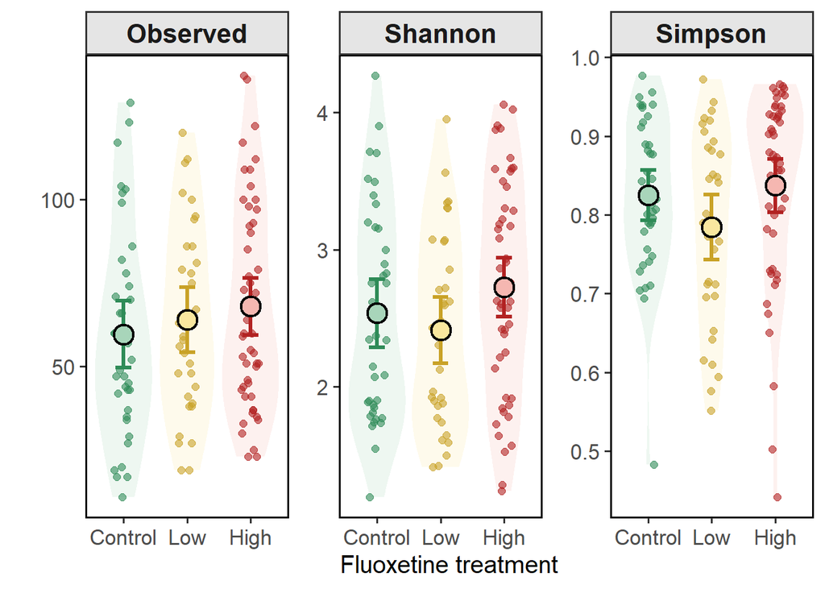

```r
# Reorder treatment levels
alpha_mtd <- alpha_mtd %>%
  mutate(
    treatment = factor(
      treatment,
      levels = c("C", "L", "H"),
      labels = c("Control", "Low", "High")
    )
  )

# Colour palettes
pastel_cols <- c(
  "Control" = "#A8D5BA",
  "Low"     = "#F9E79F",
  "High"    = "#F5B7B1"
)

dark_cols <- c(
  "Control" = "#2E8B57",
  "Low"     = "#C9A227",
  "High"    = "#B22222"
)

# Long format for plotting raw values
alpha_long <- alpha_mtd %>%
  tidyr::pivot_longer(
    cols = c("Observed", "Shannon", "Simpson"),
    names_to = "metric",
    values_to = "value"
  ) %>%
  mutate(
    metric = factor(metric, levels = c("Observed", "Shannon", "Simpson"))
  )

# Summary means and 95% CIs for visualisation
alpha_summary <- alpha_long %>%
  group_by(metric, treatment) %>%
  summarise(
    mean = mean(value, na.rm = TRUE),
    se = sd(value, na.rm = TRUE) / sqrt(sum(!is.na(value))),
    lower = mean - 1.96 * se,
    upper = mean + 1.96 * se,
    .groups = "drop"
  )

# Plot
p_alpha <- ggplot() +
  geom_violin(
    data = alpha_long,
    aes(x = treatment, y = value, fill = treatment),
    alpha = 0.20,
    colour = NA,
    trim = TRUE
  ) +
  geom_jitter(
    data = alpha_long,
    aes(x = treatment, y = value, colour = treatment),
    width = 0.15,
    alpha = 0.60,
    size = 2
  ) +
  geom_errorbar(
    data = alpha_summary,
    aes(
      x = treatment,
      ymin = lower,
      ymax = upper,
      colour = treatment
    ),
    width = 0.25,
    linewidth = 1.2
  ) +
  geom_point(
    data = alpha_summary,
    aes(
      x = treatment,
      y = mean,
      fill = treatment
    ),
    shape = 21,
    size = 5,
    stroke = 1.2,
    colour = "black"
  ) +
  facet_wrap(~metric, scales = "free_y") +
  scale_fill_manual(values = pastel_cols) +
  scale_colour_manual(values = dark_cols) +
  theme_bw(base_size = 14) +
  labs(
    x = "Fluoxetine treatment",
    y = ""
  ) +
  theme(
    strip.background = element_rect(fill = "grey90", linewidth = 1),
    strip.text = element_text(size = 16, face = "bold"),
    axis.text = element_text(size = 13),
    axis.title = element_text(size = 15),
    panel.grid = element_blank(),
    legend.position = "none",
    panel.border = element_rect(colour = "black", linewidth = 1),
    panel.spacing = unit(1.2, "lines")
  )

print(p_alpha)
```

```r
ggsave(
  filename = here::here("figures", "alpha_diversity.pdf"),
  plot = p_alpha,
  width = 9,
  height = 4.5
)

ggsave(
  filename = here::here("figures", "alpha_diversity.jpg"),
  plot = p_alpha,
  width = 9,
  height = 4.5,
  dpi = 600
)
```

# Beta diversity

Measures community differences between treatments.

## Setup

First, we’ll need to transform the counts so that we account for the number of sequences. Values will no longer be counts, but rather the dominance for each taxa relative to the geometric mean of all taxa on the logarithmic scale

### Apply a centred log-ratio transformation to the filtered ASV count data. This transformation treats the microbiome data as compositional and produces values suitable for Euclidean-distance-based ordination and beta-diversity analysis.

```r
# CLR transformation
ps_clr <- microbiome::transform(ps_NB, "clr")
# The values are now no longer counts, but a value of dominance for each taxa
```

Next, conduct the Principle Component Analysis (PCA), examine the relative importance of each PC, and generate the ordination.

### Perform a principal-component ordination of the CLR-transformed community data and display a scree plot. The scree plot shows the proportion of total community variation represented by each ordination axis.

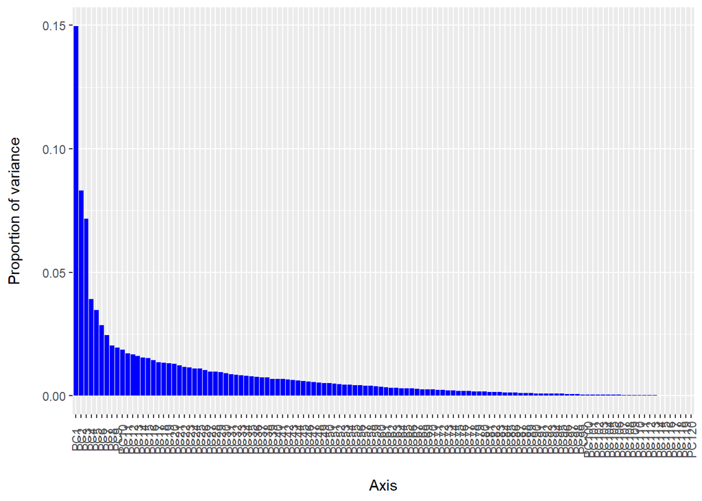

```r
# Generate the principal components
ord_clr <- ordinate(ps_clr, "RDA")

# Plot to examine the proportion of total variation explained by each PC
plot_scree(ord_clr) +
  geom_bar(stat = "identity", fill = "blue") +
  labs(x = "\nAxis", y = "Proportion of variance\n")
```

```r
# Examine the Eigen values () and the the proportion of variance explained
head(ord_clr$CA$eig)
```

```
##       PC1       PC2       PC3       PC4       PC5       PC6
## 132.57283  73.56566  63.54937  34.57442  30.67046  25.35299
```

```r
sapply(ord_clr$CA$eig[1:5], function(x) x / sum(ord_clr$CA$eig))
```

```
##        PC1        PC2        PC3        PC4        PC5
## 0.14974391 0.08309403 0.07178040 0.03905256 0.03464296
```

## Plot ordination

### Calculate the variance explained by the first two ordination axes. These proportions are subsequently used to preserve the appropriate aspect ratio in the PCA plots.

```r
# Plot the first two components
# We'll scale the plot to reflect the relative amount of information explained by each axis
clr1 <- ord_clr$CA$eig[1] / sum(ord_clr$CA$eig)
clr2 <- ord_clr$CA$eig[2] / sum(ord_clr$CA$eig)
```

### Create an exploratory PCA plot with treatment-specific points, 95% confidence ellipses, and marginal density distributions.

```r
png("./PCA_temp_1.png", width = 300, height = 225, units='mm', res = 300)
plot_ordination(ps_NB, ord_clr, type = "samples") +
  coord_fixed(clr1/clr2) +
  stat_ellipse(aes(group = treatment, colour = treatment, fill = treatment),
               geom = "polygon",
               alpha = 0.1,
               linetype = 1,
               linewidth = 0.8,
               level = 0.95) +
    geom_point(aes(fill = treatment),
             size = 2,
             alpha = 0.8,
             shape = 21) +
  scale_fill_manual(values = c("C" = "#7FA6B8",
                               "L" = "#F3AD7A",
                               "H" = "#EC6C31")) +
  scale_colour_manual(values = c("C" = "#7FA6B8",
                                 "L" = "#F3AD7A",
                                 "H" = "#EC6C31")) +
  theme_bw(base_size = 14) +
  geom_xsidedensity(aes(fill = treatment),
                    alpha = 0.5,
                    show.legend = FALSE) +
  geom_ysidedensity(aes(fill = treatment),
                    alpha = 0.5,
                    show.legend = FALSE) +
#  geom_xsideboxplot(aes(fill = treatment, y = treatment),
#                    orientation = "y") +
#  geom_ysideboxplot(aes(fill = treatment, x = treatment),
#                    orientation = "x") +
#  scale_xsidey_discrete(labels = NULL) +
#  scale_ysidex_discrete(labels = NULL) +
  theme_ggside_void()
dev.off()
```

```r
ord_df <- plot_ordination(ps_NB, ord_clr, type = "samples", justDF = TRUE)
png("./PCA_temp_2.png", width = 300, height = 225, units='mm', res = 300)
ggplot(ord_df, aes(x = PC1, y = PC2)) +
  coord_fixed(clr1/clr2) +
    stat_ellipse(aes(group = treatment, colour = treatment),
               alpha = 1,
               linetype = 1,
               linewidth = 1,
               level = 0.95) +
      geom_point(aes(colour = treatment),
             size = 5,
             alpha = 0.8) +
  scale_fill_manual(values = c("C" = "#7FA6B8",
                               "L" = "#F3AD7A",
                               "H" = "#EC6C31")) +
  scale_colour_manual(values = c("C" = "#7FA6B8",
                                 "L" = "#F3AD7A",
                                 "H" = "#EC6C31")) +
  theme_bw(base_size = 14) +
  theme(legend.position = "right",
        legend.title = element_blank(),
        axis.title = element_text(size = 20),
        axis.text = element_text(size = 18),
        axis.line = element_line(color = "black",
                                 linewidth = 0.6),
        panel.border = element_rect(fill = NA,
                                    color = "black",
                                    linewidth = 1.5),
        axis.ticks.length = unit(0.25, "cm"),
        legend.text = element_text(size = 18)) +
  xlab(paste0("PC1 (", round(clr1*100, 1), "%)")) +
  ylab(paste0("PC2 (", round(clr2*100, 1), "%)"))
dev.off()
```

It looks like there might be some separate clustering, suggesting possible differences in microbial communities according to treatment. We’ll use a permutational multivariate analysis of variance (PERMANOVA) to test whether the samples cluster beyond that expected. Note that PERMANOVA is analogous to ANOVA, but is for multivariate distance data.

## Permanova

### Calculate Euclidean distances among samples using the CLR-transformed ASV table and test for treatment-related differences in community composition with PERMANOVA. This is equivalent to testing Aitchison distances because Euclidean distance is applied after CLR transformation.

```r
# Generate Euclidean distance matrix on the clr-transformed ASV data
clr_dist_matrix <- phyloseq::distance(ps_clr, method = "euclidean")

# Create metadata frame as pairwise.adonis2 doesn't accept vectors
meta <- data.frame(sample_data(ps_clr))

# PERMANOVA (ADONIS) test
adonis2(clr_dist_matrix ~ treatment,
        data = meta)
```

```
## Permutation test for adonis under reduced model
## Permutation: free
## Number of permutations: 999
##
## adonis2(formula = clr_dist_matrix ~ treatment, data = meta)
##           Df SumOfSqs      R2      F Pr(>F)
## Model      2     2020 0.01901 1.1434  0.232
## Residual 118   104220 0.98099
## Total    120   106240 1.00000
```

```r
#adonis2(clr_dist_matrix ~ sample_data(ps_clr)$treatment)
# formula = clr_dist_matrix ~ sample_data(ps_clr)$treatment
```

### Prepare the relative-abundance phyloseq object for taxonomic-composition plots and define a reusable plotting function. The function aggregates taxa at a selected rank, retains the most abundant groups, combines the remainder as ‘Other’, and creates faceted stacked-bar plots.

```r
# Taxonomic composition plots

# 1. Prepare object for taxonomic plots
# ps_tss should already be filtered and transformed to relative abundance
ps_tax_plot <- ps_tss

# Optional: check ranks
rank_names(ps_tax_plot)
```

```
## [1] "Domain"  "Phylum"  "Class"   "Order"   "Family"  "Genus"   "Species"
```

```r
# Make sure treatment is ordered
sample_data(ps_tax_plot)$treatment <- factor(
  sample_data(ps_tax_plot)$treatment,
  levels = c("C", "L", "H")
)

# ------------------------------------------------------------
# 2. Function for composition plots
# ------------------------------------------------------------

make_tax_composition_plot <- function(ps_obj,
                                      tax_rank = "Phylum",
                                      top_n = 10,
                                      x_var = "sample",
                                      facet_var = "treatment") {

  # Agglomerate taxa at selected rank
  ps_glom <- tax_glom(ps_obj, taxrank = tax_rank, NArm = FALSE)

  # Convert to long format
  tax_df <- psmelt(ps_glom)

  # Rename missing/unclassified taxa
  tax_df[[tax_rank]] <- as.character(tax_df[[tax_rank]])
  tax_df[[tax_rank]][is.na(tax_df[[tax_rank]]) | tax_df[[tax_rank]] == ""] <- "Unclassified"

  # Identify most abundant taxa
  top_taxa <- tax_df %>%
    group_by(.data[[tax_rank]]) %>%
    summarise(mean_abundance = mean(Abundance, na.rm = TRUE), .groups = "drop") %>%
    arrange(desc(mean_abundance)) %>%
    slice_head(n = top_n) %>%
    pull(.data[[tax_rank]])

  # Collapse low-abundance taxa into Other
  tax_df <- tax_df %>%
    mutate(
      Taxon = ifelse(.data[[tax_rank]] %in% top_taxa,
                     .data[[tax_rank]],
                     "Other"),
      Taxon = factor(Taxon)
    )

  # Order taxa by mean abundance, keeping Other last
  tax_order <- tax_df %>%
    group_by(Taxon) %>%
    summarise(mean_abundance = mean(Abundance, na.rm = TRUE), .groups = "drop") %>%
    arrange(desc(mean_abundance)) %>%
    pull(Taxon)

  tax_order <- c(setdiff(tax_order, "Other"), "Other")

  tax_df$Taxon <- factor(tax_df$Taxon, levels = rev(tax_order))

  # Plot
  ggplot(tax_df, aes(x = .data[[x_var]], y = Abundance, fill = Taxon)) +
    geom_bar(stat = "identity", width = 0.95) +
    facet_grid(
      cols = vars(.data[[facet_var]]),
      scales = "free_x",
      space = "free_x"
    ) +
    scale_y_continuous(
      labels = percent_format(accuracy = 1),
      expand = c(0, 0)
    ) +
    labs(
      x = "Samples",
      y = "Relative abundance",
      fill = tax_rank
    ) +
    theme_bw(base_size = 14) +
    theme(
      panel.grid = element_blank(),
      axis.text.x = element_blank(),
      axis.ticks.x = element_blank(),
      axis.title = element_text(face = "bold", colour = "black"),
      axis.text.y = element_text(colour = "black"),
      strip.text = element_text(face = "bold", colour = "black"),
      strip.background = element_rect(fill = "white", colour = "black"),
      legend.title = element_text(face = "bold", colour = "black"),
      legend.text = element_text(colour = "black"),
      legend.position = "right"
    )
}
```

### Use the reusable composition-plot function to display sample-level bacterial composition at the phylum level. The ten most abundant phyla are shown.

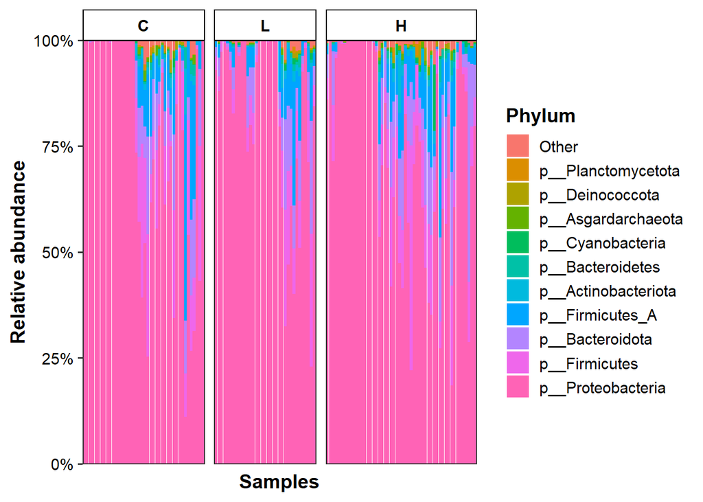

```r
# ------------------------------------------------------------
# 3.1. Phylum-level taxonomic composition
# ------------------------------------------------------------

p_phylum <- make_tax_composition_plot(
  ps_obj = ps_tax_plot,
  tax_rank = "Phylum",
  top_n = 10,
  x_var = "Sample",
  facet_var = "treatment"
)

p_phylum
```

```r
ggsave(
  filename = here("figures", "taxonomic_composition_phylum.pdf"),
  plot = p_phylum,
  width = 10,
  height = 6
)

ggsave(
  filename = here("figures", "taxonomic_composition_phylum.jpg"),
  plot = p_phylum,
  width = 10,
  height = 6,
  dpi = 600
)
```

```r
# Mean taxonomic composition per treatment (PHYLUM)


# Prepare phylum-level data

ps_phylum <- tax_glom(ps_tss, taxrank = "Phylum", NArm = FALSE)

phylum_df <- psmelt(ps_phylum) %>%
  mutate(
    Phylum = as.character(Phylum),
    Phylum = ifelse(is.na(Phylum) | Phylum == "", "Unclassified", Phylum),
    Phylum = gsub("^p__", "", Phylum),

    Phylum = case_when(
      Phylum %in% c("Firmicutes_A", "Firmicutes_B", "Firmicutes_C") ~ "Firmicutes",
      Phylum %in% c("Bacteroidetes") ~ "Bacteroidota",
      TRUE ~ Phylum
    ),

    treatment = factor(
      treatment,
      levels = c("C", "L", "H"),
      labels = c("Control", "Low", "High")
    )
  )

# Identify dominant phyla

top_phyla <- phylum_df %>%
  group_by(Phylum) %>%
  summarise(mean_abundance = mean(Abundance, na.rm = TRUE), .groups = "drop") %>%
  arrange(desc(mean_abundance)) %>%
  slice_head(n = 6) %>%
  pull(Phylum)

# Collapse rare phyla into Other at sample level

phylum_sample_summary <- phylum_df %>%
  mutate(
    Phylum_plot = ifelse(Phylum %in% top_phyla, Phylum, "Other")
  ) %>%
  group_by(treatment, Sample, Phylum_plot) %>%
  summarise(
    Abundance = sum(Abundance, na.rm = TRUE),
    .groups = "drop"
  )

# Check that each sample sums to 1
phylum_sample_summary %>%
  group_by(treatment, Sample) %>%
  summarise(total = sum(Abundance), .groups = "drop") %>%
  summarise(
    min_total = min(total),
    max_total = max(total)
  )
```

```
## # A tibble: 1 × 2
##   min_total max_total
##       <dbl>     <dbl>
## 1     0.998         1
```

```r
# Calculate mean relative abundance per treatment

phylum_summary <- phylum_sample_summary %>%
  group_by(treatment, Phylum_plot) %>%
  summarise(
    mean_abundance = mean(Abundance, na.rm = TRUE),
    .groups = "drop"
  )

# Check treatment bars sum to 1
phylum_summary %>%
  group_by(treatment) %>%
  summarise(total = sum(mean_abundance), .groups = "drop")
```

```
## # A tibble: 3 × 2
##   treatment total
##   <fct>     <dbl>
## 1 Control    1.00
## 2 Low        1.00
## 3 High       1.00
```

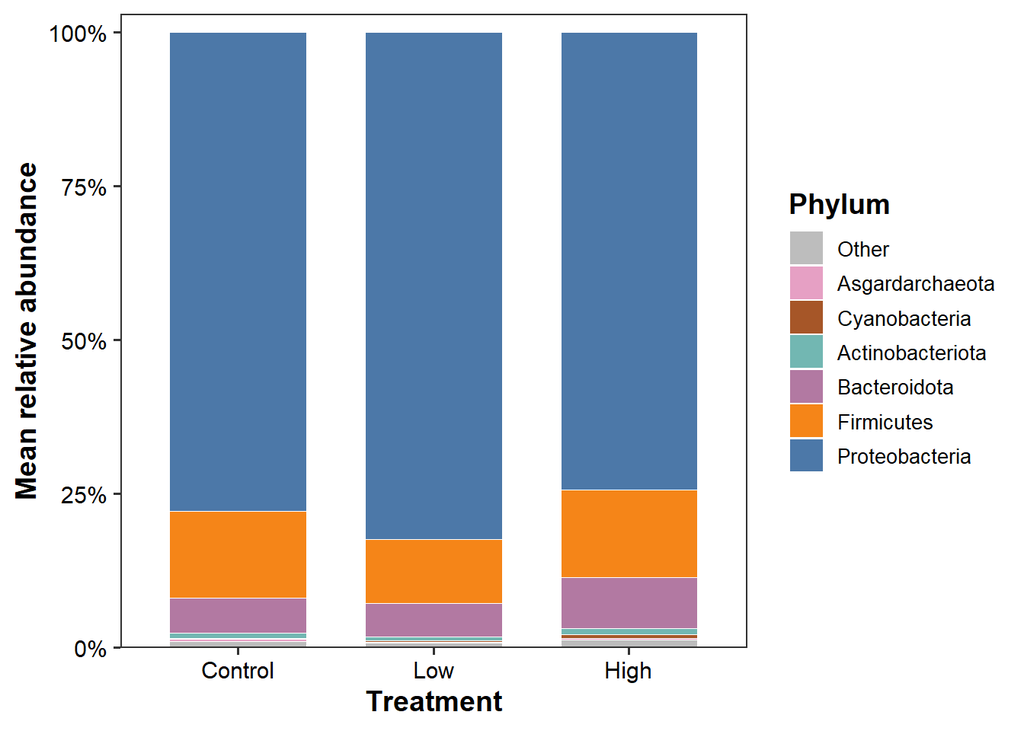

```r
# Order phyla

phyla_order <- phylum_summary %>%
  group_by(Phylum_plot) %>%
  summarise(global_mean = mean(mean_abundance), .groups = "drop") %>%
  arrange(desc(global_mean)) %>%
  pull(Phylum_plot)

phyla_order <- c(setdiff(phyla_order, "Other"), "Other")

phylum_summary <- phylum_summary %>%
  mutate(
    Phylum_plot = factor(Phylum_plot, levels = phyla_order)
  )

# Colours

# Fixed phylum palette avoiding treatment colours
phylum_cols <- c(
  "Proteobacteria"   = "#4C78A8",  # blue
  "Firmicutes"       = "#F58518",  # orange
  "Bacteroidota"     = "#B279A2",  # purple
  "Actinobacteriota" = "#72B7B2",  # teal
  "Cyanobacteria"    = "#A65628",  # brown
  "Asgardarchaeota"  = "#E6A0C4",  # pink
  "Other"            = "#BDBDBD"   # grey
)

# Keep only colours for phyla present in the plot
phylum_cols <- phylum_cols[levels(phylum_summary$Phylum_plot)]

# Safety check: stop if any phylum is missing a colour
if (any(is.na(phylum_cols))) {
  missing_cols <- levels(phylum_summary$Phylum_plot)[is.na(phylum_cols)]
  stop(
    "Missing colours for: ",
    paste(missing_cols, collapse = ", ")
  )
}

# Plot

p_phylum_mean <- ggplot(
  phylum_summary,
  aes(x = treatment, y = mean_abundance, fill = Phylum_plot)
) +
  geom_bar(
    stat = "identity",
    position = "stack",
    width = 0.7,
    colour = "white",
    linewidth = 0.2
  ) +
  scale_y_continuous(
    labels = percent_format(accuracy = 1),
    limits = c(0, 1),
    expand = expansion(mult = c(0, 0.03))
  ) +
  scale_fill_manual(values = phylum_cols) +
  guides(fill = guide_legend(reverse = TRUE)) +
  labs(
    x = "Treatment",
    y = "Mean relative abundance",
    fill = "Phylum"
  ) +
  theme_bw(base_size = 14) +
  theme(
    panel.grid = element_blank(),
    axis.title = element_text(face = "bold", colour = "black"),
    axis.text = element_text(colour = "black"),
    legend.title = element_text(face = "bold", colour = "black"),
    legend.text = element_text(colour = "black", size = 10),
    legend.key.size = unit(0.6, "cm"),
    legend.position = "right"
  )

p_phylum_mean
```

```r
# Save figure

ggsave(
  filename = here("figures", "phylum_mean_composition_final.pdf"),
  plot = p_phylum_mean,
  width = 6,
  height = 5
)

ggsave(
  filename = here("figures", "phylum_mean_composition_final.jpg"),
  plot = p_phylum_mean,
  width = 6,
  height = 5,
  dpi = 600
)
```

### Summarise genus-level relative abundance by treatment using the same general workflow as the phylum analysis.

```r
# Genus-level taxonomic composition

# Prepare genus-level data

ps_genus <- tax_glom(ps_tss, taxrank = "Genus", NArm = FALSE)

genus_df <- psmelt(ps_genus) %>%
  mutate(
    Genus = as.character(Genus),
    Genus = ifelse(is.na(Genus) | Genus == "", "Unclassified", Genus),
    Genus = gsub("^g__", "", Genus),

    treatment = factor(
      treatment,
      levels = c("C", "L", "H"),
      labels = c("Control", "Low", "High")
    )
  )

# Identify dominant genera

top_genera <- genus_df %>%
  group_by(Genus) %>%
  summarise(mean_abundance = mean(Abundance, na.rm = TRUE), .groups = "drop") %>%
  arrange(desc(mean_abundance)) %>%
  slice_head(n = 8) %>%
  pull(Genus)

# Collapse rare genera into Other at sample level

genus_sample_summary <- genus_df %>%
  mutate(
    Genus_plot = ifelse(Genus %in% top_genera, Genus, "Other")
  ) %>%
  group_by(treatment, Sample, Genus_plot) %>%
  summarise(
    Abundance = sum(Abundance, na.rm = TRUE),
    .groups = "drop"
  )

# Check that each sample sums to 1
genus_sample_summary %>%
  group_by(treatment, Sample) %>%
  summarise(total = sum(Abundance), .groups = "drop") %>%
  summarise(
    min_total = min(total),
    max_total = max(total)
  )
```

```
## # A tibble: 1 × 2
##   min_total max_total
##       <dbl>     <dbl>
## 1     0.998         1
```

```r
# Calculate mean relative abundance per treatment

genus_summary <- genus_sample_summary %>%
  group_by(treatment, Genus_plot) %>%
  summarise(
    mean_abundance = mean(Abundance, na.rm = TRUE),
    .groups = "drop"
  )

# Check treatment bars sum to 1
genus_summary %>%
  group_by(treatment) %>%
  summarise(total = sum(mean_abundance), .groups = "drop")
```

```
## # A tibble: 3 × 2
##   treatment total
##   <fct>     <dbl>
## 1 Control    1.00
## 2 Low        1.00
## 3 High       1.00
```

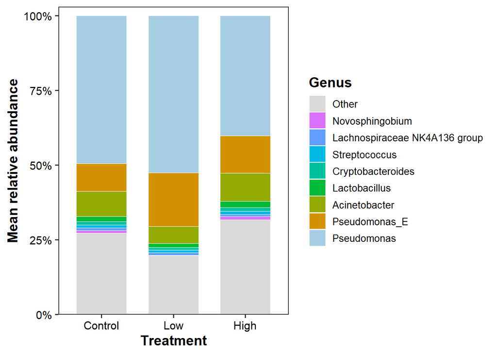

```r
# Order genera by global abundance, with Other last

genus_order <- genus_summary %>%
  group_by(Genus_plot) %>%
  summarise(global_mean = mean(mean_abundance), .groups = "drop") %>%
  arrange(desc(global_mean)) %>%
  pull(Genus_plot)

genus_order <- c(setdiff(genus_order, "Other"), "Other")

genus_summary <- genus_summary %>%
  mutate(
    Genus_plot = factor(Genus_plot, levels = genus_order)
  )

# Manual colour palette

n_genera <- length(levels(genus_summary$Genus_plot))

genus_cols <- scales::hue_pal()(n_genera)
names(genus_cols) <- levels(genus_summary$Genus_plot)

if ("Pseudomonas" %in% names(genus_cols)) {
  genus_cols["Pseudomonas"] <- "#A6CEE3"
}

if ("Other" %in% names(genus_cols)) {
  genus_cols["Other"] <- "grey85"
}

# Plot

p_genus_mean <- ggplot(
  genus_summary,
  aes(x = treatment, y = mean_abundance, fill = Genus_plot)
) +
  geom_bar(
    stat = "identity",
    position = "stack",
    width = 0.7,
    colour = "white",
    linewidth = 0.2
  ) +
  scale_y_continuous(
    labels = percent_format(accuracy = 1),
    limits = c(0, 1),
    expand = expansion(mult = c(0, 0.03))
  ) +
  scale_fill_manual(values = genus_cols) +
  guides(fill = guide_legend(reverse = TRUE)) +
  labs(
    x = "Treatment",
    y = "Mean relative abundance",
    fill = "Genus"
  ) +
  theme_bw(base_size = 14) +
  theme(
    panel.grid = element_blank(),
    axis.title = element_text(face = "bold", colour = "black"),
    axis.text = element_text(colour = "black"),
    legend.title = element_text(face = "bold", colour = "black"),
    legend.text = element_text(colour = "black", size = 10),
    legend.key.size = unit(0.6, "cm"),
    legend.position = "right"
  )

p_genus_mean
```

```r
# Save figure

ggsave(
  filename = here("figures", "genus_mean_composition_final.pdf"),
  plot = p_genus_mean,
  width = 7,
  height = 5
)

ggsave(
  filename = here("figures", "genus_mean_composition_final.jpg"),
  plot = p_genus_mean,
  width = 7,
  height = 5,
  dpi = 600
)
```

### Construct the final beta-diversity ordination using principal coordinates analysis of Aitchison distances.

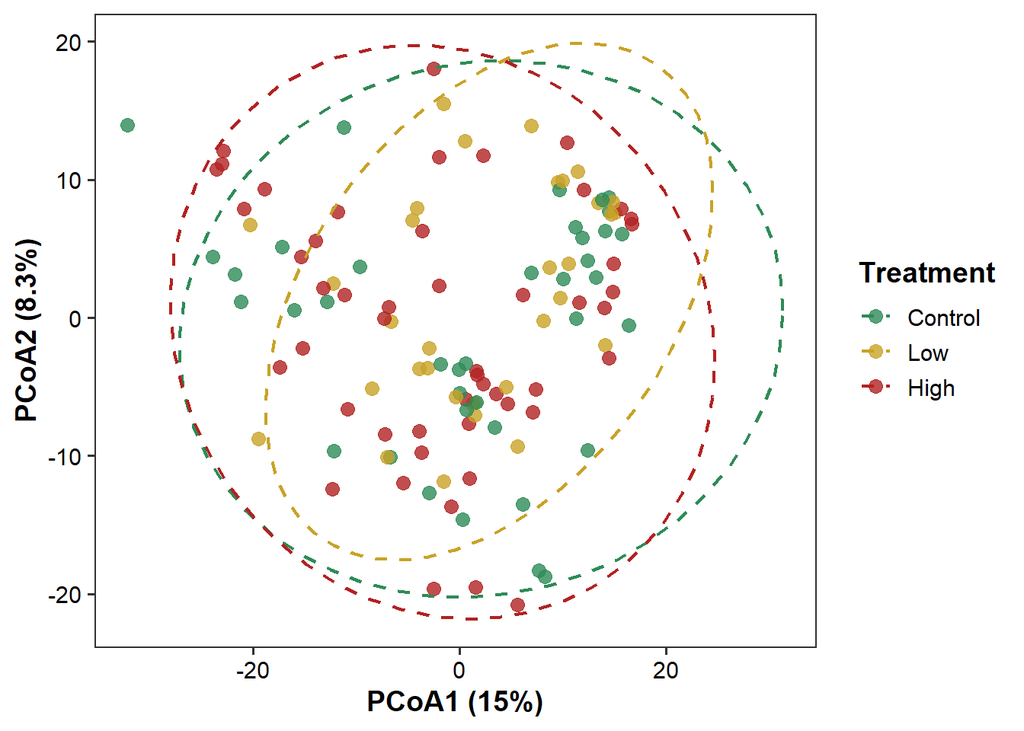

```r
# Beta diversity: PCoA (CLR-transformed data)

# CLR transformation

ps_clr <- microbiome::transform(ps_NB, "clr")

# Distance matrix (Aitchison = Euclidean on CLR)

clr_mat <- as(otu_table(ps_clr), "matrix")

# Ensure taxa are columns
if (taxa_are_rows(ps_clr)) {
  clr_mat <- t(clr_mat)
}

clr_dist <- dist(clr_mat, method = "euclidean")

# PCoA

pcoa_res <- cmdscale(clr_dist, eig = TRUE, k = 2)

# Extract coordinates
pcoa_df <- as.data.frame(pcoa_res$points)
colnames(pcoa_df) <- c("PCoA1", "PCoA2")

# Add metadata

meta_df <- data.frame(sample_data(ps_clr))

pcoa_df <- pcoa_df %>%
  mutate(
    Sample = rownames(pcoa_df)
  ) %>%
  left_join(
    meta_df %>% rownames_to_column("Sample"),
    by = "Sample"
  )

# Format treatment
pcoa_df$treatment <- factor(
  pcoa_df$treatment,
  levels = c("C", "L", "H"),
  labels = c("Control", "Low", "High")
)

# Variance explained

eig_vals <- pcoa_res$eig

var_explained <- eig_vals / sum(eig_vals)

pc1_var <- round(var_explained[1] * 100, 1)
pc2_var <- round(var_explained[2] * 100, 1)

# Plot

p_pcoa <- ggplot(pcoa_df, aes(x = PCoA1, y = PCoA2, colour = treatment)) +
  geom_point(size = 3, alpha = 0.8) +

  # Ellipses (visual grouping only)
  stat_ellipse(
    aes(group = treatment),
    type = "t",
    linetype = 2,
    linewidth = 0.8
  ) +

  scale_colour_manual(values = c(
    "Control" = "#2E8B57",
    "Low" = "#C9A227",
    "High" = "#B22222"
  )) +

  labs(
    x = paste0("PCoA1 (", pc1_var, "%)"),
    y = paste0("PCoA2 (", pc2_var, "%)"),
    colour = "Treatment"
  ) +

  theme_bw(base_size = 14) +
  theme(
    panel.grid = element_blank(),
    axis.title = element_text(face = "bold", colour = "black"),
    axis.text = element_text(colour = "black"),
    legend.title = element_text(face = "bold"),
    legend.position = "right"
  )

p_pcoa
```

```r
# Save figure

ggsave(
  filename = here("figures", "pcoa_clr.pdf"),
  plot = p_pcoa,
  width = 6,
  height = 5
)

ggsave(
  filename = here("figures", "pcoa_clr.jpg"),
  plot = p_pcoa,
  width = 6,
  height = 5,
  dpi = 600
)
```

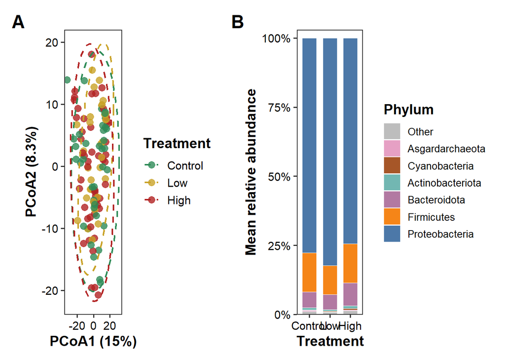

```r
# Merge figures
figure_microbiome <- (
  p_pcoa +
  p_phylum_mean +
  plot_layout(widths = c(1.4, 1.6))
) +
  plot_annotation(tag_levels = "A") &
  theme(
    plot.tag = element_text(
      size = 18,
      face = "bold"
    )
  )

figure_microbiome
```

```r
ggsave(
  filename = here("figures", "beta_phylum.pdf"),
  plot = figure_microbiome,
  width = 12,
  height = 5
)

ggsave(
  filename = here("figures", "beta_phylum.jpg"),
  plot = figure_microbiome,
  width = 12,
  height = 5,
  dpi = 600
)
```

## Sequencing depth quality control

### Create a helper function for extracting sample sequencing depths from phyloseq objects, then compare read counts before and after filtering. The resulting table quantifies reads removed and the proportion retained for every sample.

```r
# Helper function: extract sample read depths

get_sample_depths <- function(ps_object, depth_name) {

  df <- data.frame(
    sample = sample_names(ps_object),
    reads = sample_sums(ps_object)
  )

  colnames(df)[2] <- depth_name

  df
}

# Read depth before taxonomic/prevalence filtering
depth_raw <- get_sample_depths(
  ps_object = ps_NB_raw,
  depth_name = "reads_before_filtering"
)

depth_filtered <- get_sample_depths(
  ps_object = ps_NB,
  depth_name = "reads_after_filtering"
)

# Combine before and after read depths
depth_comparison <- full_join(
  depth_raw,
  depth_filtered,
  by = "sample"
) %>%
  mutate(
    reads_removed = reads_before_filtering - reads_after_filtering,
    proportion_retained = reads_after_filtering / reads_before_filtering,
    percent_retained = 100 * proportion_retained,
    percent_removed = 100 - percent_retained
  ) %>%
  arrange(reads_after_filtering)

depth_comparison
```

```
##            sample reads_before_filtering reads_after_filtering reads_removed
## 1    93HT10.fastq                   1128                  1050            78
## 2     68HT8.fastq                   1179                  1090            89
## 3     24HT3.fastq                   1697                  1237           460
## 4     27HT3.fastq                   2633                  1820           813
## 5     81CT9.fastq                   5646                  2145          3501
## 6    96LT21.fastq                   2432                  2424             8
## 7     42CT5.fastq                   4435                  2621          1814
## 8     23HT3.fastq                   3519                  3309           210
## 9   112LT12.fastq                   4624                  3455          1169
## 10   60HT17.fastq                  22617                  3604         19013
## 11    69HT8.fastq                  12524                  3748          8776
## 12   92HT10.fastq                   5697                  3886          1811
## 13    82CT9.fastq                   4973                  4395           578
## 14    22HT3.fastq                   6669                  5234          1435
```

[output cut: 245 more lines]

### Summarise the dimensions and sequencing depth of the microbiome dataset before and after filtering.

```r
# Number of samples before and after filtering
sample_summary <- tibble(
  dataset = c("Before filtering", "After filtering"),
  n_samples = c(nsamples(ps_NB_raw), nsamples(ps_NB)),
  n_ASVs = c(ntaxa(ps_NB_raw), ntaxa(ps_NB)),
  total_reads = c(
    sum(sample_sums(ps_NB_raw)),
    sum(sample_sums(ps_NB))
  ),
  mean_reads = c(
    mean(sample_sums(ps_NB_raw)),
    mean(sample_sums(ps_NB))
  ),
  median_reads = c(
    median(sample_sums(ps_NB_raw)),
    median(sample_sums(ps_NB))
  ),
  minimum_reads = c(
    min(sample_sums(ps_NB_raw)),
    min(sample_sums(ps_NB))
  ),
  maximum_reads = c(
    max(sample_sums(ps_NB_raw)),
    max(sample_sums(ps_NB))
  )
)

sample_summary
```

```
## # A tibble: 2 × 8
##   dataset     n_samples n_ASVs total_reads mean_reads median_reads minimum_reads
##   <chr>           <int>  <int>       <dbl>      <dbl>        <dbl>         <dbl>
## 1 Before fil…       129  15768     3680845     28534.        31552            11
## 2 After filt…       121    261     2927151     24191.        24109          1050
## # ℹ 1 more variable: maximum_reads <dbl>
```

### Count how many filtered samples fall below several candidate sequencing-depth thresholds.

```r
# Thresholds chosen to show the lower tail of the distribution
depth_thresholds <- c(1000, 2000, 3000, 5000, 10000)

low_depth_counts <- tibble(
  threshold = depth_thresholds,
  n_samples_below_threshold = sapply(
    depth_thresholds,
    function(x) sum(sample_sums(ps_NB) < x)
  ),
  percent_samples_below_threshold = sapply(
    depth_thresholds,
    function(x) {
      100 * mean(sample_sums(ps_NB) < x)
    }
  )
)

low_depth_counts
```

```
## # A tibble: 5 × 3
##   threshold n_samples_below_threshold percent_samples_below_threshold
##       <dbl>                     <int>                           <dbl>
## 1      1000                         0                            0
## 2      2000                         4                            3.31
## 3      3000                         7                            5.79
## 4      5000                        13                           10.7
## 5     10000                        20                           16.5
```

### Apply a 5,000-read diagnostic threshold and list all samples below it. This step is exploratory and identifies samples that may warrant closer inspection rather than automatically removing them.

```r
sum(sample_sums(ps_NB) < 5000)
```

```
## [1] 13
```

```r
low_depth_cutoff <- 5000

low_depth_samples <- depth_comparison %>%
  filter(reads_after_filtering < low_depth_cutoff) %>%
  arrange(reads_after_filtering)

low_depth_samples
```

```
##           sample reads_before_filtering reads_after_filtering reads_removed
## 1   93HT10.fastq                   1128                  1050            78
## 2    68HT8.fastq                   1179                  1090            89
## 3    24HT3.fastq                   1697                  1237           460
## 4    27HT3.fastq                   2633                  1820           813
## 5    81CT9.fastq                   5646                  2145          3501
## 6   96LT21.fastq                   2432                  2424             8
## 7    42CT5.fastq                   4435                  2621          1814
## 8    23HT3.fastq                   3519                  3309           210
## 9  112LT12.fastq                   4624                  3455          1169
## 10  60HT17.fastq                  22617                  3604         19013
## 11   69HT8.fastq                  12524                  3748          8776
## 12  92HT10.fastq                   5697                  3886          1811
## 13   82CT9.fastq                   4973                  4395           578
##    proportion_retained percent_retained percent_removed
## 1            0.9308511         93.08511       6.9148936
## 2            0.9245123         92.45123       7.5487701
## 3            0.7289334         72.89334      27.1066588
## 4            0.6912267         69.12267      30.8773262
## 5            0.3799150         37.99150      62.0085016
## 6            0.9967105         99.67105       0.3289474
## 7            0.5909808         59.09808      40.9019166
## 8            0.9403240         94.03240       5.9676044
## 9            0.7471886         74.71886      25.2811419
## 10           0.1593492         15.93492      84.0650838
## 11           0.2992654         29.92654      70.0734590
## 12           0.6821134         68.21134      31.7886607
## 13           0.8837724         88.37724      11.6227629
```

### Join the low-depth sample list to the experimental metadata.

```r
metadata_df <- data.frame(sample_data(ps_NB)) %>%
  rownames_to_column("sample")

low_depth_samples_metadata <- low_depth_samples %>%
  left_join(metadata_df, by = "sample")

low_depth_samples_metadata
```

```
##           sample reads_before_filtering reads_after_filtering reads_removed
## 1   93HT10.fastq                   1128                  1050            78
## 2    68HT8.fastq                   1179                  1090            89
## 3    24HT3.fastq                   1697                  1237           460
## 4    27HT3.fastq                   2633                  1820           813
## 5    81CT9.fastq                   5646                  2145          3501
## 6   96LT21.fastq                   2432                  2424             8
## 7    42CT5.fastq                   4435                  2621          1814
## 8    23HT3.fastq                   3519                  3309           210
## 9  112LT12.fastq                   4624                  3455          1169
## 10  60HT17.fastq                  22617                  3604         19013
## 11   69HT8.fastq                  12524                  3748          8776
## 12  92HT10.fastq                   5697                  3886          1811
## 13   82CT9.fastq                   4973                  4395           578
##    proportion_retained percent_retained percent_removed   batch tank treatment
```

[output cut: 27 more lines]

### Plot the distribution of post-filtering read depths and mark the 5,000-read diagnostic cutoff.

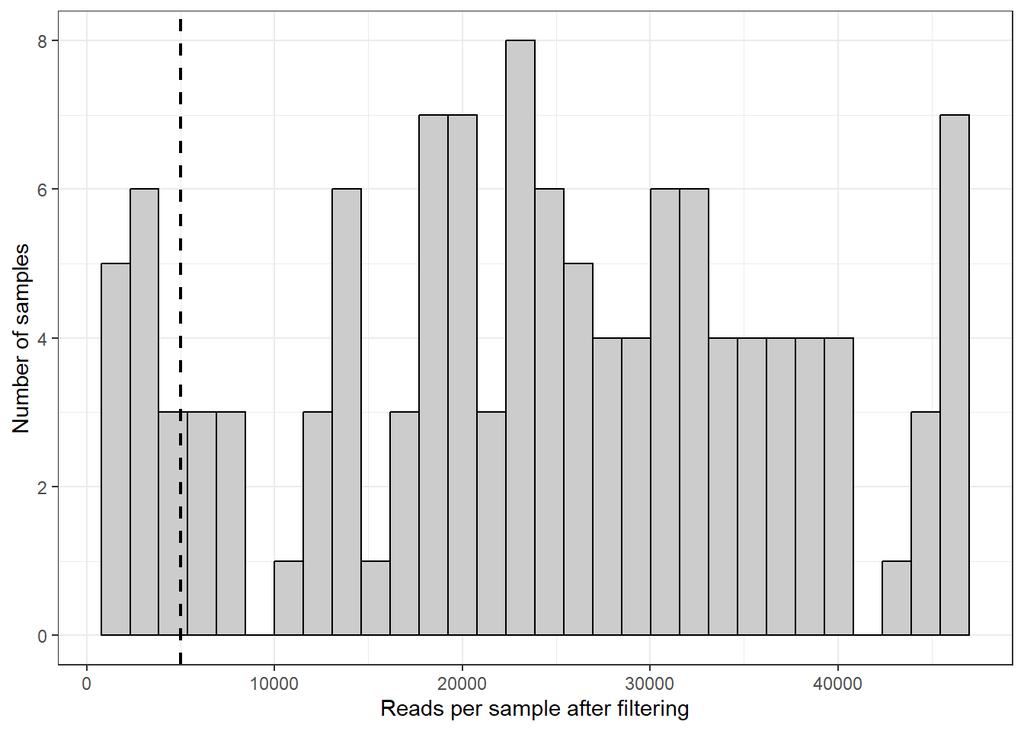

```r
ggplot(depth_comparison, aes(x = reads_after_filtering)) +
  geom_histogram(bins = 30, colour = "black", fill = "grey80") +
  geom_vline(
    xintercept = low_depth_cutoff,
    linetype = "dashed",
    linewidth = 0.8
  ) +
  labs(
    x = "Reads per sample after filtering",
    y = "Number of samples"
  ) +
  theme_bw()
```

### Compare each sample’s read depth before and after filtering.

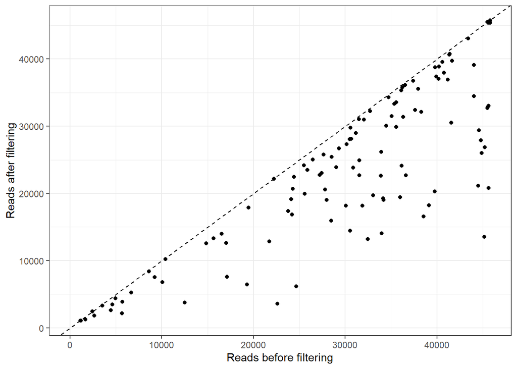

```r
ggplot(
  depth_comparison,
  aes(
    x = reads_before_filtering,
    y = reads_after_filtering
  )
) +
  geom_point() +
  geom_abline(
    intercept = 0,
    slope = 1,
    linetype = "dashed"
  ) +
  labs(
    x = "Reads before filtering",
    y = "Reads after filtering"
  ) +
  theme_bw()
```

```r
low_depth_loss_summary <- low_depth_samples_metadata %>%
  select(
    sample,
    reads_before_filtering,
    reads_after_filtering,
    reads_removed,
    percent_retained,
    percent_removed,
    everything()
  )

low_depth_loss_summary
```

```
##           sample reads_before_filtering reads_after_filtering reads_removed
## 1   93HT10.fastq                   1128                  1050            78
## 2    68HT8.fastq                   1179                  1090            89
## 3    24HT3.fastq                   1697                  1237           460
## 4    27HT3.fastq                   2633                  1820           813
## 5    81CT9.fastq                   5646                  2145          3501
## 6   96LT21.fastq                   2432                  2424             8
## 7    42CT5.fastq                   4435                  2621          1814
## 8    23HT3.fastq                   3519                  3309           210
## 9  112LT12.fastq                   4624                  3455          1169
## 10  60HT17.fastq                  22617                  3604         19013
## 11   69HT8.fastq                  12524                  3748          8776
## 12  92HT10.fastq                   5697                  3886          1811
## 13   82CT9.fastq                   4973                  4395           578
##    percent_retained percent_removed proportion_retained   batch tank treatment
```

[output cut: 27 more lines]

```r
# DETAILED QC REPORT FOR EXTREME READ-LOSS SAMPLES
# Samples identified as having unusually high read loss
samples_to_check <- c(
  "60HT17.fastq",
  "69HT8.fastq",
  "81CT9.fastq"
)

# ------------------------------------------------------------
# 1. Helper: convert phyloseq OTU table to samples x ASVs
# ------------------------------------------------------------

otu_samples_by_taxa <- function(ps_object) {

  otu <- as(otu_table(ps_object), "matrix")

  if (taxa_are_rows(ps_object)) {
    otu <- t(otu)
  }

  return(otu)
}

otu_raw <- otu_samples_by_taxa(ps_NB_raw)
otu_filtered <- otu_samples_by_taxa(ps_NB)

# Keep only samples present in both objects
samples_to_check <- intersect(
  samples_to_check,
  intersect(rownames(otu_raw), rownames(otu_filtered))
)

samples_to_check
```

```
## [1] "60HT17.fastq" "69HT8.fastq"  "81CT9.fastq"
```

```r
read_loss_report <- tibble(
  sample = samples_to_check,
  reads_before = rowSums(otu_raw[samples_to_check, , drop = FALSE]),
  reads_after = rowSums(otu_filtered[samples_to_check, , drop = FALSE])
) %>%
  mutate(
    reads_removed = reads_before - reads_after,
    percent_retained = 100 * reads_after / reads_before,
    percent_removed = 100 - percent_retained
  ) %>%
  arrange(percent_retained)

read_loss_report
```

```
## # A tibble: 3 × 6
##   sample reads_before reads_after reads_removed percent_retained percent_removed
##   <chr>         <dbl>       <dbl>         <dbl>            <dbl>           <dbl>
## 1 60HT1…        22617        3604         19013             15.9            84.1
## 2 69HT8…        12524        3748          8776             29.9            70.1
## 3 81CT9…         5646        2145          3501             38.0            62.0
```

```r
taxonomy_raw <- as(tax_table(ps_NB_raw), "matrix") %>%
  as.data.frame() %>%
  rownames_to_column("ASV")

taxonomy_filtered <- as(tax_table(ps_NB), "matrix") %>%
  as.data.frame() %>%
  rownames_to_column("ASV")

get_top_ASVs_before <- function(sample_name, n_top = 20) {

  counts <- otu_raw[sample_name, ]

  tibble(
    sample = sample_name,
    ASV = names(counts),
    reads_before = as.numeric(counts)
  ) %>%
    filter(reads_before > 0) %>%
    mutate(
      relative_abundance_before =
        reads_before / sum(reads_before)
    ) %>%
    arrange(desc(reads_before)) %>%
    slice_head(n = n_top) %>%
    left_join(taxonomy_raw, by = "ASV") %>%
    mutate(
      retained_after_filtering =
        ASV %in% colnames(otu_filtered)
    )
}
top_ASVs_before <- bind_rows(
  lapply(
    samples_to_check,
    get_top_ASVs_before,
    n_top = 20
  )
)

top_ASVs_before
```

```
## # A tibble: 60 × 12
##    sample    ASV   reads_before relative_abundance_b…¹ Domain Phylum Class Order
##    <chr>     <chr>        <dbl>                  <dbl> <chr>  <chr>  <chr> <chr>
##  1 60HT17.f… f6de…         2067                 0.0914 d__Ba… p__Cy… c__V… o__V…
##  2 60HT17.f… d2bb…         1294                 0.0572 d__Ba… p__Pr… c__A… o__R…
##  3 60HT17.f… 58bb…          831                 0.0367 d__Ba… p__Pr… c__G… o__P…
##  4 60HT17.f… f77c…          727                 0.0321 d__Ba… p__Pr… c__A… o__R…
##  5 60HT17.f… c813…          580                 0.0256 d__Ba… p__Pr… c__A… o__R…
##  6 60HT17.f… 7fec…          489                 0.0216 d__Ba… p__Cy… c__C… o__U…
##  7 60HT17.f… b68c…          439                 0.0194 d__Ba… p__Pr… c__G… o__P…
##  8 60HT17.f… f452…          393                 0.0174 d__Ba… p__Pr… c__G… o__P…
##  9 60HT17.f… 2f94…          361                 0.0160 d__Ba… p__De… c__D… o__D…
## 10 60HT17.f… 85d8…          337                 0.0149 d__Ba… p__Pr… c__G… o__P…
## # ℹ 50 more rows
## # ℹ abbreviated name: ¹relative_abundance_before
## # ℹ 4 more variables: Family <chr>, Genus <chr>, Species <chr>,
## #   retained_after_filtering <lgl>
```

```r
top_ASVs_before %>%
  select(
    sample,
    ASV,
    reads_before,
    relative_abundance_before,
    retained_after_filtering,
    Domain,
    Phylum,
    Class,
    Order,
    Family,
    Genus,
    Species
  )
```

```
## # A tibble: 60 × 12
##    sample       ASV   reads_before relative_abundance_b…¹ retained_after_filte…²
##    <chr>        <chr>        <dbl>                  <dbl> <lgl>
##  1 60HT17.fastq f6de…         2067                 0.0914 FALSE
##  2 60HT17.fastq d2bb…         1294                 0.0572 FALSE
##  3 60HT17.fastq 58bb…          831                 0.0367 TRUE
##  4 60HT17.fastq f77c…          727                 0.0321 FALSE
##  5 60HT17.fastq c813…          580                 0.0256 FALSE
##  6 60HT17.fastq 7fec…          489                 0.0216 FALSE
##  7 60HT17.fastq b68c…          439                 0.0194 FALSE
##  8 60HT17.fastq f452…          393                 0.0174 TRUE
##  9 60HT17.fastq 2f94…          361                 0.0160 FALSE
## 10 60HT17.fastq 85d8…          337                 0.0149 FALSE
## # ℹ 50 more rows
## # ℹ abbreviated names: ¹relative_abundance_before, ²retained_after_filtering
## # ℹ 7 more variables: Domain <chr>, Phylum <chr>, Class <chr>, Order <chr>,
## #   Family <chr>, Genus <chr>, Species <chr>
```

### Retrieve the post-filtering count for each dominant ASV identified in the flagged samples.

```r
get_after_count <- function(sample_name, ASV_name) {

  if (
    sample_name %in% rownames(otu_filtered) &&
    ASV_name %in% colnames(otu_filtered)
  ) {
    return(otu_filtered[sample_name, ASV_name])
  }

  return(0)
}

top_ASVs_comparison <- top_ASVs_before %>%
  rowwise() %>%
  mutate(
    reads_after = get_after_count(sample, ASV),
    reads_removed = reads_before - reads_after
  ) %>%
  ungroup() %>%
  mutate(
    percent_of_ASV_reads_retained =
      100 * reads_after / reads_before
  )

top_ASVs_comparison %>%
  select(
    sample,
    ASV,
    reads_before,
    reads_after,
    reads_removed,
    relative_abundance_before,
    retained_after_filtering,
    percent_of_ASV_reads_retained,
    Phylum,
    Class,
    Order,
    Family,
    Genus
  )
```

```
## # A tibble: 60 × 13
##    sample    ASV   reads_before reads_after reads_removed relative_abundance_b…¹
##    <chr>     <chr>        <dbl>       <dbl>         <dbl>                  <dbl>
##  1 60HT17.f… f6de…         2067           0          2067                 0.0914
##  2 60HT17.f… d2bb…         1294           0          1294                 0.0572
##  3 60HT17.f… 58bb…          831         831             0                 0.0367
##  4 60HT17.f… f77c…          727           0           727                 0.0321
##  5 60HT17.f… c813…          580           0           580                 0.0256
##  6 60HT17.f… 7fec…          489           0           489                 0.0216
##  7 60HT17.f… b68c…          439           0           439                 0.0194
##  8 60HT17.f… f452…          393         393             0                 0.0174
##  9 60HT17.f… 2f94…          361           0           361                 0.0160
## 10 60HT17.f… 85d8…          337           0           337                 0.0149
## # ℹ 50 more rows
## # ℹ abbreviated name: ¹relative_abundance_before
## # ℹ 7 more variables: retained_after_filtering <lgl>,
## #   percent_of_ASV_reads_retained <dbl>, Phylum <chr>, Class <chr>,
## #   Order <chr>, Family <chr>, Genus <chr>
```

```r
ASV_dataset_context <- tibble(
  ASV = colnames(otu_raw),
  total_reads_all_samples = colSums(otu_raw),
  prevalence_n_samples = colSums(otu_raw > 0),
  prevalence_percent =
    100 * colSums(otu_raw > 0) / nrow(otu_raw),
  mean_reads_when_present = apply(
    otu_raw,
    2,
    function(x) {
      if (sum(x > 0) == 0) return(0)
      mean(x[x > 0])
    }
  ),
  median_reads_when_present = apply(
    otu_raw,
    2,
    function(x) {
      if (sum(x > 0) == 0) return(0)
      median(x[x > 0])
    }
  )
)

top_ASVs_context <- top_ASVs_comparison %>%
  left_join(
    ASV_dataset_context,
    by = "ASV"
  ) %>%
  arrange(sample, desc(reads_before))

top_ASVs_context %>%
  select(
    sample,
    ASV,
    reads_before,
    reads_after,
    relative_abundance_before,
    retained_after_filtering,
    prevalence_n_samples,
    prevalence_percent,
    total_reads_all_samples,
    Phylum,
    Class,
    Order,
    Family,
    Genus
  )
```

```
## # A tibble: 60 × 14
##    sample       ASV              reads_before reads_after relative_abundance_b…¹
##    <chr>        <chr>                   <dbl>       <dbl>                  <dbl>
##  1 60HT17.fastq f6def16d9f0bdb2…         2067           0                 0.0914
##  2 60HT17.fastq d2bbfb63a265093…         1294           0                 0.0572
##  3 60HT17.fastq 58bb23bea5bd92b…          831         831                 0.0367
##  4 60HT17.fastq f77c2dac04b729c…          727           0                 0.0321
##  5 60HT17.fastq c813a8f18826cad…          580           0                 0.0256
##  6 60HT17.fastq 7fec9a1b36bf739…          489           0                 0.0216
##  7 60HT17.fastq b68c6dbcf015630…          439           0                 0.0194
##  8 60HT17.fastq f45212225ec4acd…          393         393                 0.0174
##  9 60HT17.fastq 2f94acb211410bd…          361           0                 0.0160
## 10 60HT17.fastq 85d8f15cff2892f…          337           0                 0.0149
## # ℹ 50 more rows
## # ℹ abbreviated name: ¹relative_abundance_before
## # ℹ 9 more variables: retained_after_filtering <lgl>,
## #   prevalence_n_samples <dbl>, prevalence_percent <dbl>,
## #   total_reads_all_samples <dbl>, Phylum <chr>, Class <chr>, Order <chr>,
## #   Family <chr>, Genus <chr>
```

### Run basic integrity checks on the final filtered phyloseq object before differential-abundance analysis. The checks confirm sample and ASV counts, sequencing-depth ranges, and the presence of the treatment and tank metadata variables required by the model.

```r
# BASIC CHECKS

ps_NB
```

```
## phyloseq-class experiment-level object
## otu_table()   OTU Table:         [ 261 taxa and 121 samples ]
## sample_data() Sample Data:       [ 121 samples by 6 sample variables ]
## tax_table()   Taxonomy Table:    [ 261 taxa by 7 taxonomic ranks ]
## phy_tree()    Phylogenetic Tree: [ 261 tips and 260 internal nodes ]
```

```r
nsamples(ps_NB)
```

```
## [1] 121
```

```r
ntaxa(ps_NB)
```

```
## [1] 261
```

```r
summary(sample_sums(ps_NB))
```

```
##    Min. 1st Qu.  Median    Mean 3rd Qu.    Max.
##    1050   15920   24109   24191   33314   45727
```

```r
range(sample_sums(ps_NB))
```

```
## [1]  1050 45727
```

```r
# Inspect metadata column names
colnames(sample_data(ps_NB))
```

```
## [1] "batch"            "tank"             "treatment"        "mucus_collection"
## [5] "body_mass"        "body_length"
```

```r
# Confirm treatment and tank are present
stopifnot(
  "treatment" %in% colnames(sample_data(ps_NB)),
  "tank" %in% colnames(sample_data(ps_NB))
)
```

```r
ps_NB <- prune_taxa(
  taxa_sums(ps_NB) > 0,
  ps_NB
)
```

### Prepare raw count data for genus-level MaAsLin2 analysis.

```r
# AGGREGATE RAW COUNTS TO GENUS LEVEL

# Remove taxa without a usable genus assignment
ps_genus_maaslin <- subset_taxa(
  ps_NB,
  !is.na(Genus) &
    Genus != "" &
    Genus != "g__Unclassified" &
    Genus != "Unclassified"
)

# Agglomerate ASVs belonging to the same genus
ps_genus_maaslin <- tax_glom(
  ps_genus_maaslin,
  taxrank = "Genus",
  NArm = TRUE
)

# Remove taxa with zero counts, if any
ps_genus_maaslin <- prune_taxa(
  taxa_sums(ps_genus_maaslin) > 0,
  ps_genus_maaslin
)

ps_genus_maaslin
```

```
## phyloseq-class experiment-level object
## otu_table()   OTU Table:         [ 94 taxa and 121 samples ]
## sample_data() Sample Data:       [ 121 samples by 6 sample variables ]
## tax_table()   Taxonomy Table:    [ 94 taxa by 7 taxonomic ranks ]
## phy_tree()    Phylogenetic Tree: [ 94 tips and 93 internal nodes ]
```

```r
nsamples(ps_genus_maaslin)
```

```
## [1] 121
```

```r
ntaxa(ps_genus_maaslin)
```

```
## [1] 94
```

```r
# EXTRACT GENUS COUNT TABLE

genus_counts <- as(
  otu_table(ps_genus_maaslin),
  "matrix"
)

# Ensure samples are rows and genera are columns
if (taxa_are_rows(ps_genus_maaslin)) {
  genus_counts <- t(genus_counts)
}

genus_counts <- as.data.frame(genus_counts)

dim(genus_counts)
```

```
## [1] 121  94
```

```r
genus_counts[1:5, 1:min(5, ncol(genus_counts))]
```

```
##             fbc779618aaa9b646521c851d62c44f5 99a951a0284421d43576cb7e419da7ab
## 71HT8.fastq                               63                               45
## 43CT5.fastq                               96                               13
## 50HT6.fastq                              102                               32
## 22HT3.fastq                               70                               13
## 24HT3.fastq                                0                                7
##             d300be85e9ecad978cf61d6647d69533 136d82554ab7106de96c960173880df5
## 71HT8.fastq                                0                                0
## 43CT5.fastq                                0                                0
## 50HT6.fastq                                6                                0
## 22HT3.fastq                                0                                0
## 24HT3.fastq                                0                                0
##             b6350b8c38434860f75f0933d9bc1567
## 71HT8.fastq                               75
## 43CT5.fastq                               19
## 50HT6.fastq                               33
## 22HT3.fastq                               34
## 24HT3.fastq                                0
```

```r
# ASSIGN READABLE GENUS NAMES

genus_taxonomy <- as.data.frame(
  tax_table(ps_genus_maaslin)
)

genus_taxonomy$Genus <- as.character(genus_taxonomy$Genus)

# Remove GTDB-style genus prefix
genus_taxonomy$Genus <- gsub(
  "^g__",
  "",
  genus_taxonomy$Genus
)

# Ensure names are syntactically valid and unique
genus_names <- make.unique(
  make.names(genus_taxonomy$Genus)
)

# Taxonomy rows correspond to genus-count columns
colnames(genus_counts) <- genus_names

# Confirm unique names
anyDuplicated(colnames(genus_counts))
```

```
## [1] 0
```

```r
# Should return 0

head(colnames(genus_counts))
```

```
## [1] "SOKP01"            "Cutibacterium"     "Streptomyces"
## [4] "Bifidobacterium"   "Bifidobacterium.1" "Microbacterium"
```

```r
# PREPARE SAMPLE METADATA

maaslin_metadata <- data.frame(
  sample_data(ps_genus_maaslin)
)

# Ensure row names are sample IDs
head(rownames(maaslin_metadata))
```

```
## [1] "71HT8.fastq"   "43CT5.fastq"   "50HT6.fastq"   "22HT3.fastq"
## [5] "24HT3.fastq"   "107LT11.fastq"
```

```r
head(rownames(genus_counts))
```

```
## [1] "71HT8.fastq"   "43CT5.fastq"   "50HT6.fastq"   "22HT3.fastq"
## [5] "24HT3.fastq"   "107LT11.fastq"
```

```r
# Add sequencing depth based on the final filtered ASV object
maaslin_metadata$reads <- sample_sums(ps_NB)[
  rownames(maaslin_metadata)
]

maaslin_metadata$log_reads <- log(
  maaslin_metadata$reads
)

# Treatment: set Control as reference
maaslin_metadata$treatment <- factor(
  maaslin_metadata$treatment,
  levels = c("C", "L", "H"),
  labels = c("Control", "Low", "High")
)

# Tank must be categorical
maaslin_metadata$tank <- factor(
  maaslin_metadata$tank
)

# Check treatment sample sizes
table(maaslin_metadata$treatment)
```

```
##
## Control     Low    High
##      38      33      50
```

```r
# Check tank replication
table(maaslin_metadata$tank)
```

```
##
##  3  4  5  6  7  8  9 10 11 12 13 14 15 17 18 19 20 21 22 23 24
##  7  5  7  7  5  7  3  5  7  7  7  2  7  6  4  7  7  6  6  5  4
```

```r
# Mean number of fish per tank
mean(table(maaslin_metadata$tank))
```

```
## [1] 5.761905
```

```r
# ALIGN SAMPLE ORDER

common_samples <- intersect(
  rownames(genus_counts),
  rownames(maaslin_metadata)
)

length(common_samples)
```

```
## [1] 121
```

```r
genus_counts <- genus_counts[
  common_samples,
  ,
  drop = FALSE
]

maaslin_metadata <- maaslin_metadata[
  common_samples,
  ,
  drop = FALSE
]

# Put metadata in exactly the same order
maaslin_metadata <- maaslin_metadata[
  rownames(genus_counts),
  ,
  drop = FALSE
]

# Confirm perfect alignment
stopifnot(
  identical(
    rownames(genus_counts),
    rownames(maaslin_metadata)
  )
)

dim(genus_counts)
```

```
## [1] 121  94
```

```r
dim(maaslin_metadata)
```

```
## [1] 121   8
```

```r
# CHECK GENUS PREVALENCE AND ABUNDANCE BEFORE MAASLIN

# Relative abundance only for QC summaries
genus_relative_abundance <- sweep(
  as.matrix(genus_counts),
  1,
  rowSums(genus_counts),
  "/"
)

genus_prevalence <- colMeans(
  genus_counts > 0
)

genus_mean_abundance <- colMeans(
  genus_relative_abundance,
  na.rm = TRUE
)

genus_filter_summary <- tibble(
  Genus = colnames(genus_counts),
  prevalence = genus_prevalence,
  prevalence_percent = genus_prevalence * 100,
  mean_relative_abundance = genus_mean_abundance
) %>%
  arrange(desc(mean_relative_abundance))

genus_filter_summary
```

```
## # A tibble: 94 × 4
##    Genus                    prevalence prevalence_percent mean_relative_abunda…¹
##    <chr>                         <dbl>              <dbl>                  <dbl>
##  1 Pseudomonas                   1                  100                  0.543
##  2 Pseudomonas_E                 1                  100                  0.139
##  3 Acinetobacter                 1                  100                  0.104
##  4 Lactobacillus                 0.678               67.8                0.0247
##  5 Novosphingobium               0.851               85.1                0.0135
##  6 Massilia                      0.785               78.5                0.0127
##  7 Cryptobacteroides             0.554               55.4                0.0115
##  8 Priestia                      0.512               51.2                0.0107
##  9 Lachnospiraceae.NK4A136…      0.603               60.3                0.0107
## 10 Odoribacter                   0.496               49.6                0.00966
## # ℹ 84 more rows
## # ℹ abbreviated name: ¹mean_relative_abundance
```

```r
# OUTPUT DIRECTORY

maaslin_output <- here(
  "outputs",
  "maaslin2_genus"
)

# Remove an old output directory before rerunning
# Uncomment only when you deliberately want to overwrite it
#
# if (dir.exists(maaslin_output)) {
#   unlink(maaslin_output, recursive = TRUE)
# }

dir.create(
  maaslin_output,
  recursive = TRUE,
  showWarnings = FALSE
)
```

### Fit the genus-level MaAsLin2 model. Treatment and sequencing depth are included as fixed effects, tank is included as a random effect, Control is the reference group, and multiple testing is controlled using the Benjamini-Hochberg false-discovery-rate procedure.

```r
set.seed(123)

fit_maaslin2_genus <- Maaslin2::Maaslin2(
  input_data = genus_counts,
  input_metadata = maaslin_metadata,
  output = maaslin_output,

  fixed_effects = c(
    "treatment",
    "log_reads"
  ),

  random_effects = c(
    "tank"
  ),

  reference = "treatment,Control",

  normalization = "TSS",
  transform = "LOG",
  analysis_method = "LM",

  min_prevalence = 0.10,
  min_abundance = 0.0001,

  correction = "BH",
  standardize = FALSE,

  max_significance = 0.05,
  plot_heatmap = TRUE,
  plot_scatter = TRUE,

  save_models = TRUE
)
```

[output not shown]

```
## boundary (singular) fit: see help('isSingular')
```

[output not shown]

```
## boundary (singular) fit: see help('isSingular')
```

[output not shown]

```
## boundary (singular) fit: see help('isSingular')
```

[output not shown]

```
## boundary (singular) fit: see help('isSingular')
```

[output not shown]

```
## boundary (singular) fit: see help('isSingular')
```

[output not shown]

```
## boundary (singular) fit: see help('isSingular')
```

```
## 2026-07-17 10:43:19 INFO::Fitting model to feature number 79, Priestia
## 2026-07-17 10:43:19 INFO::Fitting model to feature number 80, Niallia
```

```
## boundary (singular) fit: see help('isSingular')
```

```
## 2026-07-17 10:43:19 INFO::Fitting model to feature number 81, Rossellomorea
```

```
## boundary (singular) fit: see help('isSingular')
```

[output not shown]

```
## boundary (singular) fit: see help('isSingular')
```

[output not shown]

```
## 2026-07-17 10:43:20 INFO::Creating scatter plot for continuous data, log_reads vs Lachnospiraceae.NK4A136.group
```

```
## 2026-07-17 10:43:20 INFO::Creating scatter plot for continuous data, log_reads vs Bradyrhizobium
```

```
## 2026-07-17 10:43:20 INFO::Creating scatter plot for continuous data, log_reads vs Ileibacterium
```

```
## 2026-07-17 10:43:20 INFO::Creating scatter plot for continuous data, log_reads vs ZC4RG30
```

```
## 2026-07-17 10:43:20 INFO::Creating scatter plot for continuous data, log_reads vs Desulfovibrio.1
```

```
## 2026-07-17 10:43:21 INFO::Creating scatter plot for continuous data, log_reads vs Methylobacterium
```

```
## 2026-07-17 10:43:21 INFO::Creating scatter plot for continuous data, log_reads vs Paramuribaculum
```

```r
maaslin_all_results <- read_tsv(
  file.path(
    maaslin_output,
    "all_results.tsv"
  ),
  show_col_types = FALSE
)

glimpse(maaslin_all_results)
```

```
## Rows: 282
## Columns: 9
## $ feature  <chr> "Faecalibaculum", "Lachnospiraceae.NK4A136.group", "Bradyrhiz…
## $ metadata <chr> "log_reads", "log_reads", "log_reads", "log_reads", "log_read…
## $ value    <chr> "log_reads", "log_reads", "log_reads", "log_reads", "log_read…
## $ coef     <dbl> -1.4375619, -1.5258643, 0.9062531, -0.6077490, 0.7966353, -0.…
## $ stderr   <dbl> 0.2831713, 0.3619090, 0.2296691, 0.1596529, 0.2211724, 0.2320…
## $ N        <dbl> 121, 121, 121, 121, 121, 121, 121, 121, 121, 121, 121, 121, 1…
## $ N.not.0  <dbl> 49, 73, 41, 27, 29, 37, 76, 54, 55, 67, 19, 23, 22, 59, 54, 8…
## $ pval     <dbl> 1.473397e-06, 5.067538e-05, 1.398818e-04, 2.579998e-04, 4.730…
## $ qval     <dbl> 0.0004154979, 0.0071452291, 0.0131488875, 0.0181889876, 0.025…
```

```r
maaslin_all_results %>%
  arrange(qval) %>%
  head(20)
```

```
## # A tibble: 20 × 9
##    feature            metadata value   coef stderr     N N.not.0    pval    qval
##    <chr>              <chr>    <chr>  <dbl>  <dbl> <dbl>   <dbl>   <dbl>   <dbl>
##  1 Faecalibaculum     log_rea… log_… -1.44   0.283   121      49 1.47e-6 4.15e-4
##  2 Lachnospiraceae.N… log_rea… log_… -1.53   0.362   121      73 5.07e-5 7.15e-3
##  3 Bradyrhizobium     log_rea… log_…  0.906  0.230   121      41 1.40e-4 1.31e-2
##  4 Ileibacterium      log_rea… log_… -0.608  0.160   121      27 2.58e-4 1.82e-2
##  5 ZC4RG30            log_rea… log_…  0.797  0.221   121      29 4.73e-4 2.52e-2
##  6 Desulfovibrio.1    log_rea… log_… -0.826  0.232   121      37 5.37e-4 2.52e-2
##  7 Methylobacterium   log_rea… log_…  1.04   0.316   121      76 1.34e-3 4.99e-2
##  8 Paramuribaculum    log_rea… log_… -1.09   0.335   121      54 1.42e-3 4.99e-2
##  9 CAG.485            log_rea… log_… -1.16   0.374   121      55 2.50e-3 7.82e-2
## 10 Cryptobacteroides  log_rea… log_… -1.28   0.426   121      67 3.27e-3 8.69e-2
## 11 Stenotrophomonas   log_rea… log_… -0.400  0.133   121      19 3.39e-3 8.69e-2
## 12 Moraxella_A        treatme… Low   -1.43   0.440   121      23 4.26e-3 1.00e-1
## 13 Mucispirillum      log_rea… log_… -0.382  0.136   121      22 5.81e-3 1.26e-1
## 14 Methylobacterium.… log_rea… log_…  0.899  0.324   121      59 6.73e-3 1.36e-1
## 15 SOKP01             log_rea… log_… -0.781  0.296   121      54 9.41e-3 1.49e-1
## 16 Lactobacillus      log_rea… log_… -1.04   0.386   121      82 8.17e-3 1.49e-1
## 17 Duncaniella        log_rea… log_… -0.847  0.321   121      59 9.52e-3 1.49e-1
## 18 Muribaculum        log_rea… log_… -0.836  0.315   121      49 9.02e-3 1.49e-1
## 19 Moraxella          log_rea… log_… -0.654  0.250   121      30 1.01e-2 1.50e-1
## 20 Thiomicrorhabdus   log_rea… log_… -0.971  0.382   121      37 1.25e-2 1.64e-1
```

```r
treatment_results <- maaslin_all_results %>%
  filter(metadata == "treatment") %>%
  arrange(qval, pval)

treatment_results
```

```
## # A tibble: 188 × 9
##    feature          metadata  value   coef stderr     N N.not.0    pval  qval
##    <chr>            <chr>     <chr>  <dbl>  <dbl> <dbl>   <dbl>   <dbl> <dbl>
##  1 Moraxella_A      treatment Low   -1.43   0.440   121      23 0.00426 0.100
##  2 Phaeobacter      treatment High  -0.769  0.326   121      14 0.0303  0.300
##  3 Pseudomonas_E    treatment Low    0.986  0.503   121     121 0.0649  0.426
##  4 Microbacterium   treatment Low    0.688  0.349   121      15 0.0720  0.452
##  5 Stenotrophomonas treatment High   0.644  0.334   121      19 0.0721  0.452
##  6 Phaeobacter      treatment Low   -0.665  0.358   121      14 0.0802  0.472
##  7 Turicibacter     treatment High  -0.671  0.380   121      16 0.0994  0.549
##  8 HIMB11           treatment Low    0.639  0.388   121      24 0.102   0.555
##  9 Hylemonella      treatment Low   -1.02   0.601   121      64 0.109   0.569
## 10 Microbacterium   treatment High   0.539  0.318   121      15 0.116   0.594
## # ℹ 178 more rows
```

```r
unique(treatment_results$value)
```

```
## [1] "Low"  "High"
```

### Identify treatment-associated genera that remain significant after false-discovery-rate correction at q < 0.05.

```r
significant_treatment_results <- treatment_results %>%
  filter(qval < 0.05) %>%
  arrange(qval)

significant_treatment_results
```

```
## # A tibble: 0 × 9
## # ℹ 9 variables: feature <chr>, metadata <chr>, value <chr>, coef <dbl>,
## #   stderr <dbl>, N <dbl>, N.not.0 <dbl>, pval <dbl>, qval <dbl>
```

```r
nrow(significant_treatment_results)
```

```
## [1] 0
```

### Add effect-direction and approximate fold-change interpretations to the treatment results. Positive coefficients indicate higher abundance than Control, whereas negative coefficients indicate lower abundance.

```r
treatment_results_interpreted <- treatment_results %>%
  mutate(
    approximate_fold_change = exp(coef),
    direction = case_when(
      coef > 0 ~ "Higher than Control",
      coef < 0 ~ "Lower than Control",
      TRUE ~ "No change"
    )
  ) %>%
  arrange(qval)

treatment_results_interpreted %>%
  select(
    feature,
    value,
    coef,
    approximate_fold_change,
    direction,
    pval,
    qval,
    N,
    N.not.0
  )
```

```
## # A tibble: 188 × 9
##    feature     value   coef approximate_fold_cha…¹ direction    pval  qval     N
##    <chr>       <chr>  <dbl>                  <dbl> <chr>       <dbl> <dbl> <dbl>
##  1 Moraxella_A Low   -1.43                   0.239 Lower th… 0.00426 0.100   121
##  2 Phaeobacter High  -0.769                  0.463 Lower th… 0.0303  0.300   121
##  3 Pseudomona… Low    0.986                  2.68  Higher t… 0.0649  0.426   121
##  4 Microbacte… Low    0.688                  1.99  Higher t… 0.0720  0.452   121
##  5 Stenotroph… High   0.644                  1.90  Higher t… 0.0721  0.452   121
##  6 Phaeobacter Low   -0.665                  0.514 Lower th… 0.0802  0.472   121
##  7 Turicibact… High  -0.671                  0.511 Lower th… 0.0994  0.549   121
##  8 HIMB11      Low    0.639                  1.89  Higher t… 0.102   0.555   121
##  9 Hylemonella Low   -1.02                   0.361 Lower th… 0.109   0.569   121
## 10 Microbacte… High   0.539                  1.71  Higher t… 0.116   0.594   121
## # ℹ 178 more rows
## # ℹ abbreviated name: ¹approximate_fold_change
## # ℹ 1 more variable: N.not.0 <dbl>
```

```r
genus_long <- genus_counts %>%
  rownames_to_column("sample") %>%
  pivot_longer(
    cols = -sample,
    names_to = "feature",
    values_to = "count"
  ) %>%
  left_join(
    maaslin_metadata %>%
      rownames_to_column("sample") %>%
      select(
        sample,
        treatment,
        tank,
        reads
      ),
    by = "sample"
  ) %>%
  mutate(
    detected = count > 0
  )

genus_support <- genus_long %>%
  group_by(
    feature,
    treatment
  ) %>%
  summarise(
    n_samples = n(),
    n_detected = sum(detected),
    prevalence_percent = 100 * mean(detected),
    median_count_when_present = ifelse(
      any(detected),
      median(count[detected]),
      NA_real_
    ),
    .groups = "drop"
  )

genus_support
```

```
## # A tibble: 282 × 6
##    feature       treatment n_samples n_detected prevalence_percent
##    <chr>         <fct>         <int>      <int>              <dbl>
##  1 Acidibacter   Control          38          4               10.5
##  2 Acidibacter   Low              33          8               24.2
##  3 Acidibacter   High             50         13               26
##  4 Acidovorax    Control          38          7               18.4
##  5 Acidovorax    Low              33          7               21.2
##  6 Acidovorax    High             50         13               26
##  7 Acinetobacter Control          38         38              100
##  8 Acinetobacter Low              33         33              100
##  9 Acinetobacter High             50         50              100
## 10 Alistipes     Control          38          6               15.8
## # ℹ 272 more rows
## # ℹ 1 more variable: median_count_when_present <dbl>
```

```r
significant_genus_support <- genus_support %>%
  filter(
    feature %in%
      significant_treatment_results$feature
  )

significant_genus_support
```

```
## # A tibble: 0 × 6
## # ℹ 6 variables: feature <chr>, treatment <fct>, n_samples <int>,
## #   n_detected <int>, prevalence_percent <dbl>, median_count_when_present <dbl>
```

```r
if (nrow(significant_treatment_results) > 0) {

  significant_genera <- unique(
    significant_treatment_results$feature
  )

  plot_data_significant <- genus_long %>%
    filter(feature %in% significant_genera) %>%
    group_by(sample) %>%
    mutate(
      relative_abundance =
        count / sum(count)
    ) %>%
    ungroup()

  p_maaslin_significant <- ggplot(
    plot_data_significant,
    aes(
      x = treatment,
      y = relative_abundance
    )
  ) +
    geom_violin(
      trim = FALSE,
      alpha = 0.3
    ) +
    geom_jitter(
      width = 0.15,
      alpha = 0.6
    ) +
    facet_wrap(
      ~ feature,
      scales = "free_y"
    ) +
    scale_y_continuous(
      labels = scales::percent_format()
    ) +
    labs(
      x = "Fluoxetine treatment",
      y = "Relative abundance"
    ) +
    theme_bw()

  p_maaslin_significant

  ggsave(
    filename = here(
      "figures",
      "maaslin2_significant_genera.pdf"
    ),
    plot = p_maaslin_significant,
    width = 9,
    height = 6
  )
}
```

```r
genus_prevalence_summary <- tibble(
  Genus = colnames(genus_counts),
  n_samples_present = colSums(genus_counts > 0),
  prevalence = colMeans(genus_counts > 0),
  prevalence_percent = 100 * colMeans(genus_counts > 0),
  total_reads = colSums(genus_counts)
) %>%
  arrange(desc(prevalence))
```

### Export the principal MaAsLin2 result and quality-control tables. Separate files are created for all treatment results, FDR-significant results, genus prevalence, and treatment-specific support summaries.

```r
write_csv(
  treatment_results_interpreted,
  file.path(
    maaslin_output,
    "treatment_results_all.csv"
  )
)

write_csv(
  significant_treatment_results,
  file.path(
    maaslin_output,
    "treatment_results_significant_q005.csv"
  )
)

write_csv(
  genus_prevalence_summary,
  file.path(
    maaslin_output,
    "genus_prevalence_summary.csv"
  )
)

write_csv(
  genus_support,
  file.path(
    maaslin_output,
    "genus_support_by_treatment.csv"
  )
)
```

### Summarise the differential-abundance analysis by reporting the number of genera tested and the number of treatment associations significant after FDR correction.

```r
n_genera_tested <- treatment_results %>%
  distinct(feature) %>%
  nrow()

n_significant <- significant_treatment_results %>%
  distinct(feature, value) %>%
  nrow()

cat(
  "Genera tested:", n_genera_tested, "\n",
  "Significant treatment associations after FDR correction:",
  n_significant, "\n"
)
```

```
## Genera tested: 94
##  Significant treatment associations after FDR correction: 0
```

```r
table(maaslin_metadata$treatment)
```

```
##
## Control     Low    High
##      38      33      50
```

```r
nrow(treatment_results)
```

```
## [1] 188
```

```r
significant_treatment_results
```

```
## # A tibble: 0 × 9
## # ℹ 9 variables: feature <chr>, metadata <chr>, value <chr>, coef <dbl>,
## #   stderr <dbl>, N <dbl>, N.not.0 <dbl>, pval <dbl>, qval <dbl>
```

```r
treatment_results_interpreted %>%
  select(
    feature,
    value,
    coef,
    pval,
    qval,
    N,
    N.not.0
  ) %>%
  head(30)
```

```
## # A tibble: 30 × 7
##    feature          value   coef    pval  qval     N N.not.0
##    <chr>            <chr>  <dbl>   <dbl> <dbl> <dbl>   <dbl>
##  1 Moraxella_A      Low   -1.43  0.00426 0.100   121      23
##  2 Phaeobacter      High  -0.769 0.0303  0.300   121      14
##  3 Pseudomonas_E    Low    0.986 0.0649  0.426   121     121
##  4 Microbacterium   Low    0.688 0.0720  0.452   121      15
##  5 Stenotrophomonas High   0.644 0.0721  0.452   121      19
##  6 Phaeobacter      Low   -0.665 0.0802  0.472   121      14
##  7 Turicibacter     High  -0.671 0.0994  0.549   121      16
##  8 HIMB11           Low    0.639 0.102   0.555   121      24
##  9 Hylemonella      Low   -1.02  0.109   0.569   121      64
## 10 Microbacterium   High   0.539 0.116   0.594   121      15
## # ℹ 20 more rows
```